# Hedonic Model Predicting Property Values in King County, WA

Tianyu Zhang

2024-03-29

# Main Report

## Introduction

The following report is commissioned by Marie-Antoinette Predictions (MAP) Inc. and aims at producing a comprehensive hedonic model that predicts for single property values in King County, WA. The model leverages the use of Ordinary Least Square (OLS) regression based machine learning, which hypothesizes and tests for linear patterns among interested influential factors and property prices.

The report utilizes a methodology in the following sequence. Firstly, a data overview is provided to explain the data sources and collection methods and supply a list of categorized summaries. Secondly, a comprehensive correlation testing, multiple scatter plots, and maps are created to provide for detailed visualizations of the patterns and geographic distributions of prices and influential factors. Thirdly, the detailed model building progress is discussed including model testing, diagnostics, and improvements. Finally, the report concludes with a series of findings and conclusions based on the final hedonic model. For detailed technical report, please refer to the Technical Addendum at the end.

Please kindly note that the primary property value dataset used for the study was last compiled in 2015. Acknowledging the time gap between then and the current moment, it is recommended for the report to be used cautiously as a general reference for real estate planning. Nonetheless, the analysis assumes the general influential factors such as housing structure, land use, demographic, access to public amenities and services, would continue to exhibit sustained patterns.

## Data Gathering

### Gathering Property-specific Factors

The major dataset include each individual property’s price, and a series of property-specific internal, structural, and condition-based features. Data cleaning is performed to remove observations with price above $5,000,000 or bedrooms above 12, which likely consist of outliers. By performing a preliminary inspection and correlation matrix plot (see Technical Addendum, Section 1), multiple strong predictors of the property value are identified. While the variables “view” and “condition” hold a relatively strong association with the price, too, they are removed from the scope of this study due to being similar qualitative predictors like the factor “grade.” A list of additional property-specific variables are added to generalize for some of the existing variables and avoid overfitting.

The following codes select and create the list of variables specified below:

*Original Variables from the Dataset*

- `bedrooms`: Total number of bedrooms in the property.
- `bathrooms`: Total number of bathrooms in the property.
- `sqft_living`: Area of total interior living space measured in square feet.
- `sqft_above`: Area of total interior living space (excluding basement) measured in square feet.
- `sqft_basement`: Area of basement measured in square feet.
- `waterfront`: Whether the property has a waterfront.
- `floors`: Total floors of the property.
- `grade`: Overall rated grade of the property.
- `year_renovated`: The year in which the property is renovated.
- `year_built`: The year in which the property is constructed.
- `sqft_living15`: Average area of total interior living space of the property’s nearest 15 neighbors measured in square feet.

Note: The listed interpretations are made with reference to study published under “https://www.slideshare.net/PawanShivhare1/predicting-king-county-house-prices”.

*Additional Variables Created*

- `tot_rooms`: Sum of total number of bedrooms and bathrooms in the property.
- `ratio_above`: Ratio of total non-basement living space to total living space.
- `bldg_age`: Age of the building since year built to 2015.
- `if_single`: A dummy variable indicating whether the property has only one floor (Y) or multiple floors (N).
- `if_renovated`: A dummy variable indicating whether the property has been renovated since its construction, Y is for Yes and N is for No.
- `if_basement`: A dummy variable indicating whether the property has a basement, Y is for Yes and N is for No.
- `bedrooms_lvl`: Categorized bedrooms into five levels based on American Community Survey’s classification:
  - L1 (1)
  - L2 (2)
  - L3 (3-4)
  - L4 (5-9)
  - L5 (10 and above)
- `lag_price`: Average property value of the property’s nearest 15 neighbors.

```r
kc_house_data <- read.csv("data/kc_house_data.csv")
kc_house.sf <- st_as_sf(kc_house_data, coords = c("long", "lat"), crs = 4326) %>%
  st_transform(crs = "EPSG:2926")

kc_house.sf <- kc_house.sf %>%
  distinct(id, .keep_all = TRUE)

kc_house.sf <- kc_house.sf %>%
  filter(!price > 5000000) %>%
  filter(!bedrooms > 12)

kc_house.sf <- kc_house.sf %>%
  select(id, price, zipcode,
    bedrooms, bathrooms, sqft_living, sqft_above, sqft_basement,
    yr_built, yr_renovated,
    floors, grade, waterfront,
    sqft_living15) %>%
  mutate(tot_rooms = bedrooms + bathrooms,
         ratio_above = sqft_above/sqft_living * 100,
         bldg_age = 2015-yr_built,
         grade = as.factor(grade),
         waterfront = as.factor(waterfront),
         if_single = ifelse(floors == 1, "Y", "N"),
         floors = as.factor(floors),
         if_renovated = ifelse(yr_renovated == 0, "N", "Y"),
         if_basement = ifelse(sqft_basement > 0, "Y", "N")
         ) %>%
  select(-yr_built, -yr_renovated) #removed unnecessary year info

bedrooms.breaks <- c(0, 1, 2, 4, 9, Inf)

kc_house.sf$bedrooms_lvl <- cut(kc_house.sf$bedrooms,
                                breaks = bedrooms.breaks, labels = c("L1", "L2", "L3", "L4", "L5"))

#calculating spatially lagged property values
coords <- st_coordinates(kc_house.sf)

neighborList <- knn2nb(knearneigh(coords, 15))

spatialWeights <- nb2listw(neighborList, style="W")

kc_house.sf$lag_price <- lag.listw(spatialWeights, kc_house.sf$price)
```

### Gathering Locational Factors

In addition to property-specific data from the major dataset, broader locational factors are captured through gathering of transportation, public health, education resources, parks, crimes, flooding, and demographic data. These information points are believed to capture property purchases’ concerns of Access to services and amenities, Community demographics, Risk factors, and the property’s Geographic proximity to high speed transit stations.

Please note that an attempt was made to collect data from year 2014-2015, including the school enrollment and demographic profile, to match the primary property value dataset; however, not all data is available from the stated time period hence would likely constitute temporal discrepancies.

*Locational Factors Gathered*

- `link_buffer`: A dummy variable indicating whether the property is within a half-mile buffer from a Link station (1 for within buffer, 0 for outside buffer).
- `sounder_buffer`: A dummy variable indicating whether the property is within a half-mile buffer from a Sounder station (1 for within buffer, 0 for outside buffer).
- `express_buffer`: A dummy variable indicating whether the property is within a half-mile buffer from an Express Bus station (1 for within buffer, 0 for outside buffer).
- `transit_buffer`: A dummy variable indicating whether the property is within a half-mile buffer from any of the three listed express transit stations (1 for within buffer, 0 for outside buffer).
- `busbuffer`: Number of bus stations within a quarter-mile buffer of the property.
- `medical_nn1`: Distance (in feet) from the property to the nearest medical facility.
- `schools.per.acre`: Number of public schools per acre within the School District the property is located in.
- `enrollment.per.acre`: Number of all-grade enrollments per acre within the School District the property is located in.
- `enrollment.per.school`: Number of enrollments per school within the School District the property is located in.
- `pct.lowInc.students`: Share of students classified as “Low Income” among all students within the School District the property is located in.
- `parks_nn1`: Distance (in feet) from the property to the nearest park.
- `parks_nn3`: Average distance (in feet) from the property to the nearest three parks.
- `crime.density`: Number of crimes per acre within the ZIP code the property is located in. Density information is used instead of average distance from crime points.
- `flooding_nn1`: Distance (in feet) from the property to the nearest flooding point.
- `pctWhite`: Share of white population within the census tract the property is located in.
- `pctBachelors`: Share of population with a Bachelor’s degree within the census tract the property is located in.
- `pctPoverty`: Share of population below the poverty line within the census tract the property is located in.

For sources of the reference data and detailed grouping categories, please refer to Technical Addendum, Section 2.

### Summary Tables of Data

All data gathered are sorted into continuous variables and categorical variables, and assigned into different categories. Steps below create a table summarizing all continuous variables with relevant statistics (mean, standard distribution, minimum, maximum, range, and standard error), and a table summarizing all categorical variables by their respective share in the primary dataset.

Find below the summary table of all continuous variables sorted into different categories.

```r
allvars.kc_house <- kc_house.sf %>%
  st_drop_geometry()

#Internal Characteristics
internal_var <- describe(allvars.kc_house[,
                        c('bedrooms', 'bathrooms',
                        'sqft_living', 'sqft_above', 'sqft_basement',
                        'tot_rooms',
                        'ratio_above',
                        'bldg_age')],
                        fast=TRUE) %>%
  mutate(category = "Internal Characteristics")

#Access to Services and Amenities
access_var <- describe(allvars.kc_house[,
                        c('busbuffer',
                          'medical_nn1',
                          'schools.per.acre', 'enrollment.per.acre',
                          'enrollment.per.school',
                          'parks_nn1', 'parks_nn3')],
                        fast=TRUE) %>%
  mutate(category = "Access to Services and Amenities")

#Demographic Characteristics
demographic_var <- describe(allvars.kc_house[,
                        c('pct.lowInc.students', 'MedHHInc',
                          'pctWhite', 'pctBachelors', 'pctPoverty')],
                        fast=TRUE) %>%
  mutate(category = "Demographic Characteristics")

#Risk
risk_var <- describe(allvars.kc_house[,
                        c('crime.density','flooding_nn1')],
                        fast=TRUE) %>%
  mutate(category = "Risk")

#Neighborhood Factors
neigh_var <- describe(allvars.kc_house[,
                        c('sqft_living15','lag_price')],
                        fast=TRUE) %>%
  mutate(category = "Neighborhood Factors")

#Creating Summary Table
options(scipen = 999)

cont.summary.stats <- rbind(internal_var, access_var, demographic_var, risk_var, neigh_var) %>%
  select(-n, -vars) %>%
  kbl(caption = "Table 1: Summary of Continuous Variables") %>%
  kable_material(c("striped", "hover"))

cont.summary.stats
```

Table 1: Summary of Continuous Variables

|  | mean | sd | min | max | range | se | category |
| --- | --- | --- | --- | --- | --- | --- | --- |
| bedrooms | 3.3695165 | 0.9062605 | 0.0000000 | 11.0000000 | 11.0000000 | 0.0061910 | Internal Characteristics |
| bathrooms | 2.1160864 | 0.7664550 | 0.0000000 | 8.0000000 | 8.0000000 | 0.0052360 | Internal Characteristics |
| sqft_living | 2080.3930838 | 909.8030111 | 290.0000000 | 13540.0000000 | 13250.0000000 | 6.2152206 | Internal Characteristics |
| sqft_above | 1789.2928878 | 823.4514903 | 290.0000000 | 9410.0000000 | 9120.0000000 | 5.6253196 | Internal Characteristics |
| sqft_basement | 291.1001960 | 441.2397938 | 0.0000000 | 4820.0000000 | 4820.0000000 | 3.0142818 | Internal Characteristics |
| tot_rooms | 5.4856029 | 1.4641878 | 0.0000000 | 16.5000000 | 16.5000000 | 0.0100024 | Internal Characteristics |
| ratio_above | 87.5537670 | 17.0930053 | 33.3333333 | 100.0000000 | 66.6666667 | 0.1167690 | Internal Characteristics |
| bldg_age | 43.9029307 | 29.3830751 | 0.0000000 | 115.0000000 | 115.0000000 | 0.2007273 | Internal Characteristics |
| busbuffer | 20.8068882 | 20.9257855 | 0.0000000 | 177.0000000 | 177.0000000 | 0.1429522 | Access to Services and Amenities |
| medical_nn1 | 6529.0383022 | 6494.4273661 | 9.0261799 | 144630.9192450 | 144621.8930652 | 44.3659765 | Access to Services and Amenities |
| schools.per.acre | 0.0010779 | 0.0004319 | 0.0000082 | 0.0022464 | 0.0022382 | 0.0000030 | Access to Services and Amenities |
| enrollment.per.acre | 0.5404818 | 0.1974392 | 0.0001806 | 0.8934949 | 0.8933143 | 0.0013503 | Access to Services and Amenities |
| enrollment.per.school | 518.0990302 | 95.0524978 | 22.0000000 | 811.8000000 | 789.8000000 | 0.6500693 | Access to Services and Amenities |
| parks_nn1 | 1280.8040687 | 1041.7404357 | 5.7346991 | 14232.6006254 | 14226.8659263 | 7.1165369 | Access to Services and Amenities |
| parks_nn3 | 1778.6447559 | 1030.8497074 | 850.0176675 | 14273.3011082 | 13423.2834407 | 7.0421380 | Access to Services and Amenities |
| pct.lowInc.students | 36.3140407 | 18.8313716 | 4.8495734 | 82.5581395 | 77.7085661 | 0.1287888 | Demographic Characteristics |
| MedHHInc | 90066.4152574 | 31630.5594883 | 12269.0000000 | 199542.0000000 | 187273.0000000 | 216.1917482 | Demographic Characteristics |
| pctWhite | 72.1678785 | 16.0174612 | 7.9203727 | 103.4893070 | 95.5689342 | 0.1094778 | Demographic Characteristics |
| pctBachelors | 1.3658319 | 1.5313501 | 0.0000000 | 16.2039292 | 16.2039292 | 0.0104666 | Demographic Characteristics |
| pctPoverty | 9.0400309 | 6.8282528 | 0.9335823 | 66.5074751 | 65.5738928 | 0.0466704 | Demographic Characteristics |
| crime.density | 2.2570649 | 4.0848246 | 0.0028816 | 17.9737809 | 17.9708993 | 0.0279050 | Risk |
| flooding_nn1 | 4520.8044973 | 3446.3896742 | 17.3113928 | 70480.5955785 | 70463.2841858 | 23.5436375 | Risk |
| sqft_living15 | 1987.6729979 | 684.7599642 | 399.0000000 | 6210.0000000 | 5811.0000000 | 4.6778635 | Neighborhood Factors |
| lag_price | 528422.1720335 | 264683.2598443 | 170852.6666667 | 2276312.0000000 | 2105459.3333333 | 1808.1549970 | Neighborhood Factors |

Find below the summary table of all categorical variables sorted into different categories.

```r
results <- list()

#Spatial Structure
struc_var <- c('floors', 'if_single', 'waterfront',
                          'if_basement', 'bedrooms_lvl')
for (var in struc_var) {
  counts <- table(allvars.kc_house[[var]])
  shares <- prop.table(counts)
  result_df <- data.frame(Type = names(shares), Share = as.vector(shares))
  result_df$Category <- "Spatial Structure"
  result_df$Name <- paste(var, result_df$Type)
  result_df <- result_df[, c("Name", "Type", "Share", "Category")]
  result_df <- result_df[, -which(names(result_df) == "Type")]
  rownames(result_df) <- NULL
  results[[var]] <- result_df
}

#Property Condition
condition_var <- c('if_renovated', 'grade')

for (var in condition_var) {
  counts <- table(allvars.kc_house[[var]])
  shares <- prop.table(counts)
  result_df <- data.frame(Type = names(shares), Share = as.vector(shares))
  result_df$Category <- "Property Condition"
  result_df$Name <- paste(var, result_df$Type)
  result_df <- result_df[, c("Name", "Type", "Share", "Category")]
  result_df <- result_df[, -which(names(result_df) == "Type")]
  rownames(result_df) <- NULL
  results[[var]] <- result_df
}

#Transit Buffer
buffer_var <- c('link_buffer', 'sounder_buffer', 'express_buffer', 'transit_buffer')

for (var in buffer_var) {
  counts <- table(allvars.kc_house[[var]])
  shares <- prop.table(counts)
  result_df <- data.frame(Type = names(shares), Share = as.vector(shares))
  result_df$Category <- "Transit Buffer"
  result_df$Name <- paste(var, result_df$Type)
  result_df <- result_df[, c("Name", "Type", "Share", "Category")]
  result_df <- result_df[, -which(names(result_df) == "Type")]
  rownames(result_df) <- NULL
  results[[var]] <- result_df
}

#Creating Summary Table
final_result <- do.call(rbind, results)

cat.summary.stats <- final_result %>%
  mutate(Share = sprintf("%.2f%%", Share * 100)) %>%
  kbl(caption = "Table 2: Summary of Categorical Variables", row.names = FALSE) %>%
  kable_material(c("striped", "hover"))

cat.summary.stats
```

Table 2: Summary of Categorical Variables

| Name | Share | Category |
| --- | --- | --- |
| floors 1 | 49.27% | Spatial Structure |
| floors 1.5 | 8.81% | Spatial Structure |
| floors 2 | 38.28% | Spatial Structure |
| floors 2.5 | 0.75% | Spatial Structure |
| floors 3 | 2.85% | Spatial Structure |
| floors 3.5 | 0.04% | Spatial Structure |
| if_single N | 50.73% | Spatial Structure |
| if_single Y | 49.27% | Spatial Structure |
| waterfront 0 | 99.25% | Spatial Structure |
| waterfront 1 | 0.75% | Spatial Structure |
| if_basement N | 60.74% | Spatial Structure |
| if_basement Y | 39.26% | Spatial Structure |
| bedrooms_lvl L1 | 0.91% | Spatial Structure |
| bedrooms_lvl L2 | 12.78% | Spatial Structure |
| bedrooms_lvl L3 | 77.42% | Spatial Structure |
| bedrooms_lvl L4 | 8.88% | Spatial Structure |
| bedrooms_lvl L5 | 0.02% | Spatial Structure |
| if_renovated N | 95.76% | Property Condition |
| if_renovated Y | 4.24% | Property Condition |
| grade 1 | 0.00% | Property Condition |
| grade 3 | 0.01% | Property Condition |
| grade 4 | 0.14% | Property Condition |
| grade 5 | 1.09% | Property Condition |
| grade 6 | 9.31% | Property Condition |
| grade 7 | 41.51% | Property Condition |
| grade 8 | 28.21% | Property Condition |
| grade 9 | 12.16% | Property Condition |
| grade 10 | 5.27% | Property Condition |
| grade 11 | 1.84% | Property Condition |
| grade 12 | 0.40% | Property Condition |
| grade 13 | 0.05% | Property Condition |
| link_buffer N | 96.34% | Transit Buffer |
| link_buffer Y | 3.66% | Transit Buffer |
| sounder_buffer N | 99.86% | Transit Buffer |
| sounder_buffer Y | 0.14% | Transit Buffer |
| express_buffer N | 90.77% | Transit Buffer |
| express_buffer Y | 9.23% | Transit Buffer |
| transit_buffer N | 88.55% | Transit Buffer |
| transit_buffer Y | 11.45% | Transit Buffer |

## Correlation and Spatial Distribution of Factors

### Correlation Test

To support model building, the second correlation matrix test among numeric variables is conducted for the expanded dataset, and visualized using a correlation plot. The correlation values between variables span across -1.0 (blue) to 1.0 (red), with -1.0 indicating perfect negative correlation, 1.0 indicating perfect positive correlation, and 0.0 indicating no correlation.

According to the plot, there is observable correlation (positive and negative inclusive) between price and bathrooms, bedrooms, sqft_living, sqft_above, sqft_basement, tot_rooms, bldg_age, busbuffer (number of bus stations within a quarter-mile buffer), schools.per.acre, enrollment.per.school, pct.lowInc.students, crime.density, access to parks (both parks_nn1 and parks_nn3), MedHHInc, pctWhite, pctBachelors, and pctPoverty.

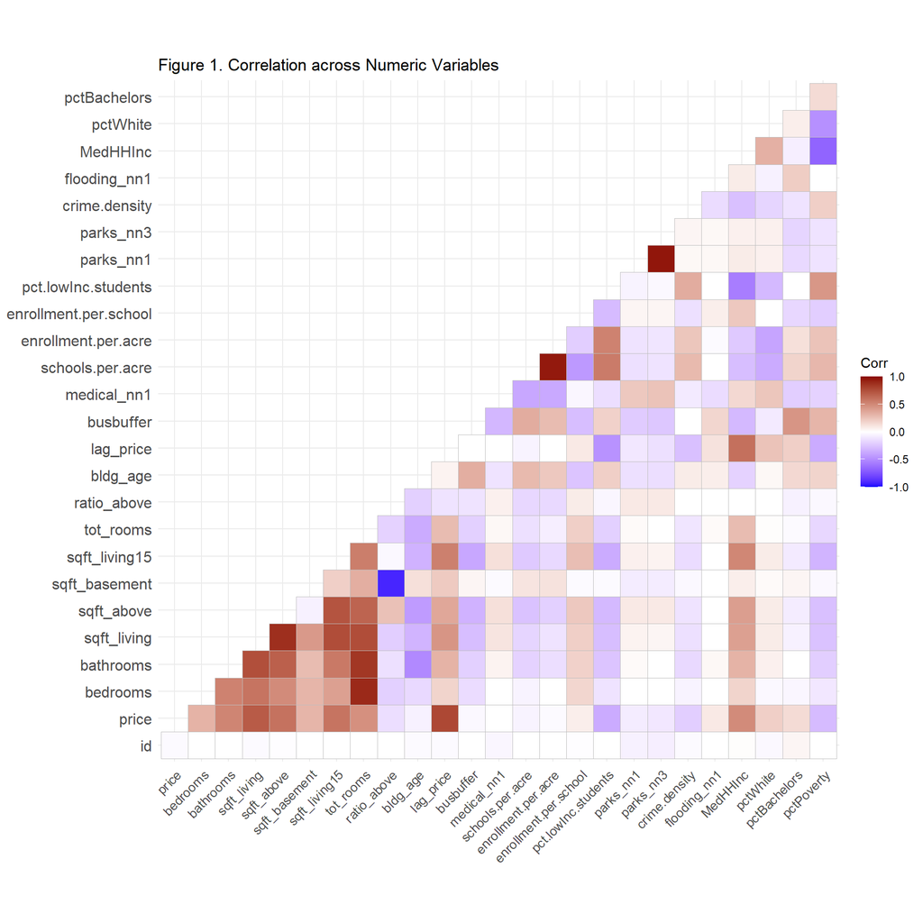

```r
#Second Correlation Matrix
kc.numeric <- kc_house.sf %>%
  st_drop_geometry() %>%
  select_if(is.numeric) %>%
  na.omit()

correlation_matrix2 <- cor(kc.numeric)

ggcorrplot(
  correlation_matrix2,
  p.mat = cor_pmat(kc.numeric),
  colors = c("blue", "white", "darkred"),
  type = "lower",
  insig = "blank"
) +
labs(title = "Figure 1. Correlation across Numeric Variables")+
theme(axis.text.x = element_text(size = 10))
```

Based on the relative magnitude of correlation, these four variables are selected: sqft_living, tot_rooms, pct.lowInc.students, and crime.density. These plots further confirm that property prices tend to increase with more spacious internal properties, which are generally considered attractive features; property prices also tend to decrease with higher crime density and higher share of low income students in the local School District, which are generally considered undesirable neighborhood qualities.

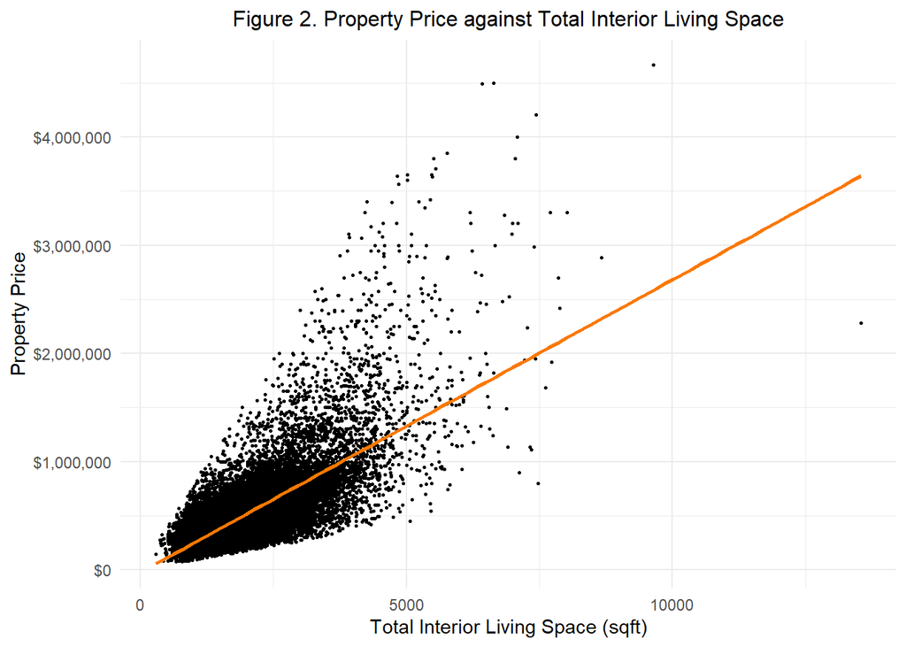

```r
ggplot(kc_house.sf, aes(sqft_living, price)) +
  geom_point(size = .5) +
  geom_smooth(method = "lm", se = FALSE, colour = "#FA7800") +
  labs(title = "Figure 2. Property Price against Total Interior Living Space") +
  theme_minimal() +
  scale_y_continuous("Property Price", labels = scales::dollar_format()) +
  scale_x_continuous("Total Interior Living Space (sqft)")+
  theme(plot.title = element_text(size = 12, hjust = 0.5))
```

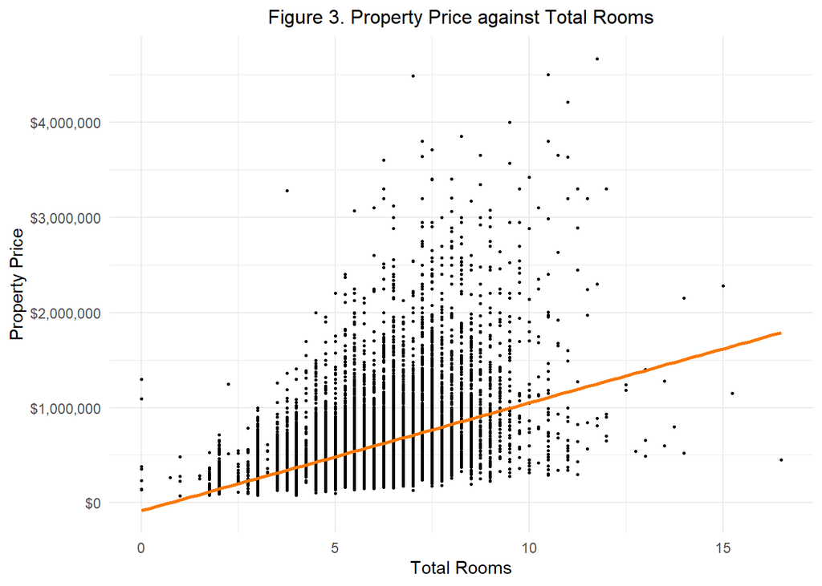

```r
ggplot(kc_house.sf, aes(tot_rooms, price)) +
  geom_point(size = .5) +
  geom_smooth(method = "lm", se = FALSE, colour = "#FA7800") +
  labs(title = "Figure 3. Property Price against Total Rooms") +
  theme_minimal() +
  scale_y_continuous("Property Price", labels = scales::dollar_format()) +
  scale_x_continuous("Total Rooms")+
  theme(plot.title = element_text(size = 12, hjust = 0.5))
```

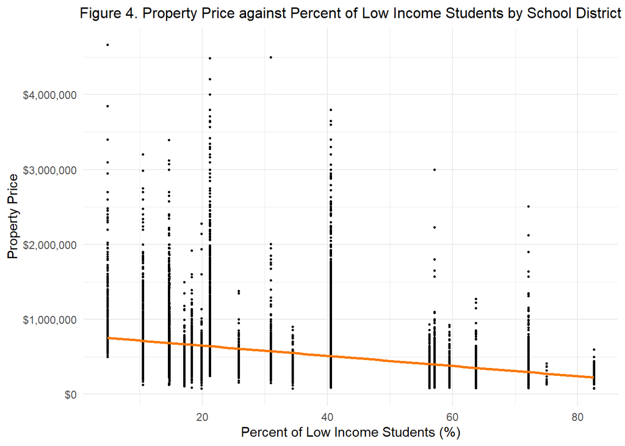

```r
ggplot(kc_house.sf, aes(pct.lowInc.students, price)) +
  geom_point(size = .5) +
  geom_smooth(method = "lm", se = FALSE, colour = "#FA7800") +
  labs(title = "Figure 4. Property Price against Percent of Low Income Students by School District") +
  theme_minimal() +
  scale_y_continuous("Property Price", labels = scales::dollar_format()) +
  scale_x_continuous("Percent of Low Income Students (%)") +
  theme(plot.title = element_text(size = 12, hjust = 0.5))
```

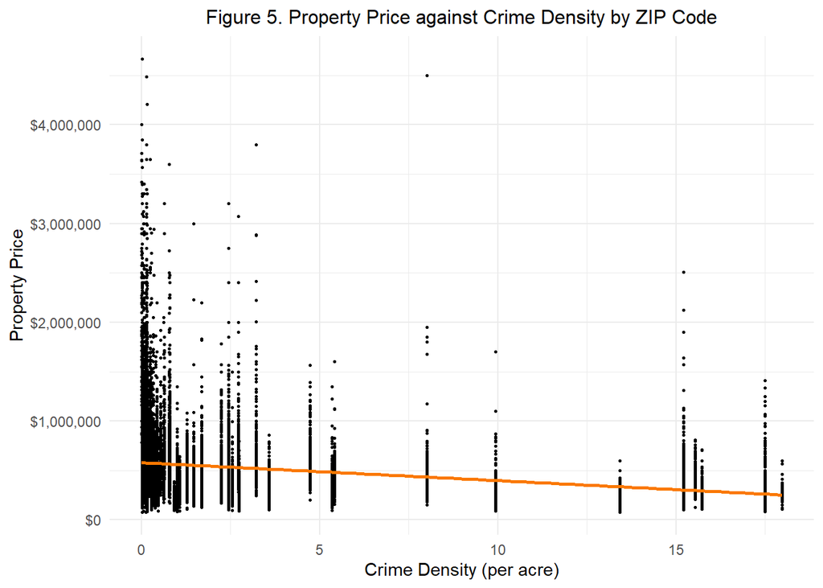

```r
ggplot(kc_house.sf, aes(crime.density, price)) +
  geom_point(size = .5) +
  geom_smooth(method = "lm", se = FALSE, colour = "#FA7800") +
  labs(title = "Figure 5. Property Price against Crime Density by ZIP Code") +
  theme_minimal()+
  scale_y_continuous("Property Price", labels = scales::dollar_format()) +
  scale_x_continuous("Crime Density (per acre)") +
  theme(plot.title = element_text(size = 12, hjust = 0.5))
```

### Spatial Distribution of Factors

Besides considering how strongly certain variables are correlated with price, maps plotting for individual property price and three selected independent variables are created below to understand the spatial patterns of price-influencing factors.

By categorizing property values in King County into equally-sized quintiles, the following map (fig. 6) indicates patterns of spatial clustering. Higher property values, particularly those in the top 20% (properties with value equal to or above 702,000 USD), predominantly concentrate in the northern half of the region. Comparatively, most properties in the southern end fall into the bottom 40% (properties with value below 399,900 USD).

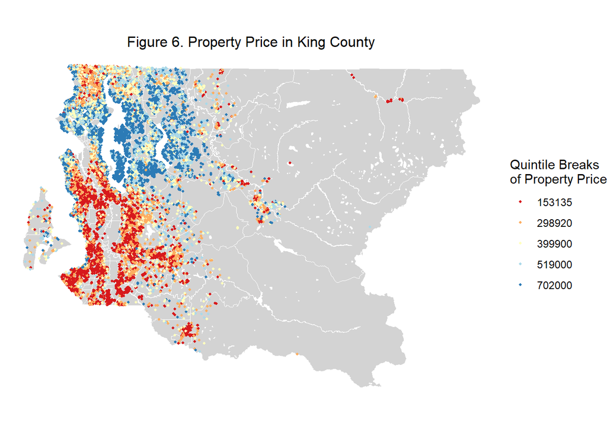

```r
palette5 <- brewer.pal(5, "RdYlBu")
tracts15 <- erase_water(tracts15)

kc_house.sf$quintiles.price <- ntile(kc_house.sf$price, 5)

ggplot() +
  geom_sf(data = tracts15, fill = "lightgrey", col = "white")+
  geom_sf(data = kc_house.sf, aes(colour = q5(price)),
          show.legend = "point", size = .75) +
  scale_colour_manual(values = palette5,
                   labels=qBr(kc_house.sf, "price"),
                   name="Quintile Breaks\nof Property Price") +
  labs(title="Figure 6. Property Price in King County") +
  theme_void()+
  theme(plot.title = element_text(size = 12, hjust = 0.5))
```

There is no obvious pattern of clustering of properties across different bedroom levels. However, there tends to be a higher share of smaller units in the region from Seattle to Renton, likely due to higher urbanization density. Most of the houses fall in L3 (3-4 bedrooms). When corresponded to the price plots, it indicates that bedroom levels alone, despite how they typically characterize real estate descriptions, does not adequately determine a property’s price.

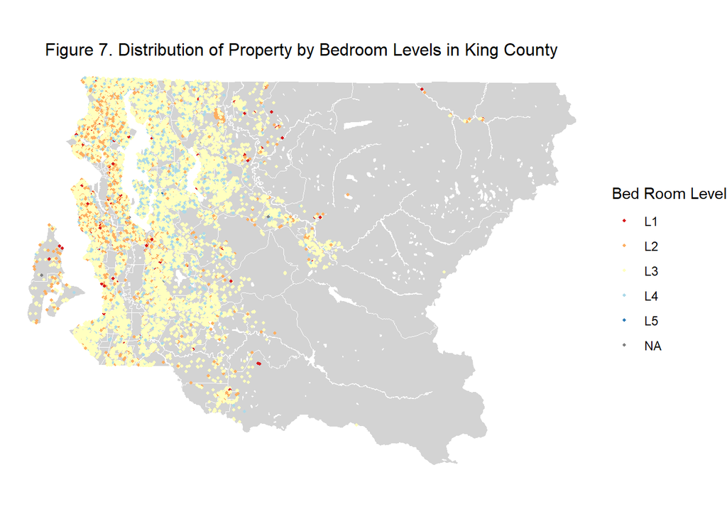

```r
ggplot() +
  geom_sf(data = tracts15, fill = "lightgrey", col = "white")+
  geom_sf(data = kc_house.sf, aes(colour = bedrooms_lvl),
          show.legend = "point", size = .75) +
  scale_colour_manual(values = palette5,
                   name="Bed Room Level") +
  labs(title="Figure 7. Distribution of Property by Bedroom Levels in King County") +
  theme_void()+
  theme(plot.title = element_text(size = 12, hjust = 0.5))
```

The share of the white population corresponding to the census tract each property is located in is divided into equally-sized quintiles and mapped in fig.8. According to the legend, most of the neighborhoods are predominantly white, and there is spatial clustering across larger geographical extent. Non-predominantly white communities generally live across the southern region of Seattle to Renton, Kent, and Federal Way.

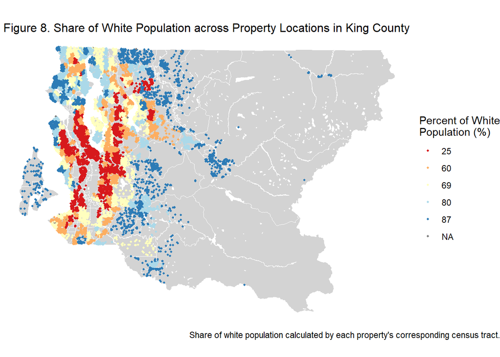

```r
kc_house.sf$quintiles.white <- ntile(kc_house.sf$pctWhite, 5)

ggplot() +
  geom_sf(data = tracts15, fill = "lightgrey", col = "white")+
  geom_sf(data = kc_house.sf, aes(colour = q5(pctWhite)),
          show.legend = "point", size = .75) +
  scale_colour_manual(values = palette5,
                   labels=qBr(kc_house.sf, "pctWhite"),
                   name="Percent of White\nPopulation (%)") +
  labs(title="Figure 8. Share of White Population across Property Locations in King County",
       caption = "Share of white population calculated by each property's corresponding census tract.") +
  theme_void()+
  theme(plot.title = element_text(size = 12, hjust = 0.5),
        plot.caption.position = "plot",
        plot.caption = element_text(hjust = 1))
```

Finally, by dividing the share of population in poverty corresponding to the census tract each property is located in, and dividing the observations into equally-sized quintiles, fig.9 also finds spatial clustering across larger geographical extent. Compared to fig.8, it’s clear that regions in the highest bracket of poverty (top 20%) generally correspond to non-predominantly white communities.

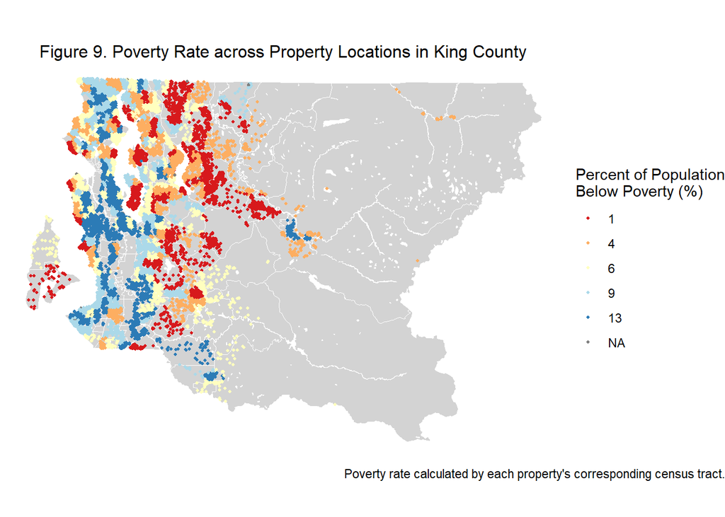

```r
kc_house.sf$quintiles.poverty <- ntile(kc_house.sf$pctPoverty, 5)

ggplot() +
  geom_sf(data = tracts15, fill = "lightgrey", col = "white")+
  geom_sf(data = kc_house.sf, aes(colour = q5(pctPoverty)),
          show.legend = "point", size = .75) +
  scale_colour_manual(values = palette5,
                   labels=qBr(kc_house.sf, "pctPoverty"),
                   name="Percent of Population\nBelow Poverty (%)") +
  labs(title="Figure 9. Poverty Rate across Property Locations in King County",
       caption = "Poverty rate calculated by each property's corresponding census tract.") +
  theme_void() +
  theme(plot.title = element_text(size = 12, hjust = 0.5),
        plot.caption.position = "plot",
        plot.caption = element_text(hjust = 1))
```

## Hedonic Model

This section presents and discusses the proposed hedonic model’s statistics and performance.

To arrive at the model, the approach unfolds in the following sequence. Firstly, by considering exploratory correlation and mapping results from the previous tests, a baseline model is tested and improved based on individual property and locational variables specific to each property, without accounting for spatial lags with its nearest 15 neighbors. Secondly, by running model diagnostics, particularly a Monte Carlo test to compute the Global Moran’s I, statistically significant spatial autocorrelation is discovered in the baseline model, indicating locational variables have insufficiently accounted for more nuanced neighborhood effects. Finally, the baseline model was improved by accounting for spatial lag effects and further diagnosis, leading to the final proposed hedonic model. For detailed testing procedure, please refer to Technical Addendum, Section 3.

Note: Certain variables including pct.Poverty (the share of population in poverty within a census tract) and transit_buffer (whether the property is located within a half-mile buffer to any of the three high speed commute’s station) was removed eventually due to perceived multicollinearity with the spatially lagged property prices. Nonetheless, they still indicated high statistical significance in the baseline model and should be considered as strong independent predictors outside of this hedonic model.

### Model Outcome

Overall, the proposed hedonic model has a 80.4% model-fit (adjusted R-squared = 0.8044). The model predicts significantly better than the mean with F-stat (24, 21320) = 3,658 (p-value < 0.05). It also satisfies the assumption of multicollinearity with all non-interaction variables’ GVIF under the threshold of 4. Based on regression coefficient analysis, there are various key factors influencing house prices in the studied area.

In general, favorable internal housing characteristics and structural characteristics generally correspond to higher property prices. For instance, property prices tend to increase with additional living square footage, above-ground ratio, bathrooms, the existence of a waterfront, or renovated condition.

However, it is further found that not all spatial expansion would correspond to increase in housing prices. For instance, when all else equal, property with 3 bedrooms and above or 3 stories and above would generally yield decreasing values as compared to ones with fewer bedrooms or stories. This may potentially indicate a preference for more spacious room size over total property unit size.

The analysis also suggests statistical significance of locational factors in predicting property prices. Access to surrounding amenities, such as schools, crime rates, and bus access, emerges as crucial factors. A higher enrollment per school is associated with a decrease in house prices, implying that buyers may prioritize areas with less crowded schools. Similarly, higher crime density correlates with lower house prices, suggesting that safety concerns influence property values. Furthermore, higher property price also correlates with additional bus stops accessible within a quarter-mile, indicating public transit access has a significant impact on housing values.

Nonetheless, we continue to see property’s value characterized by the racial profile of the neighborhood it locates in. This is indicated by higher house prices corresponding to a higher share of white population at the tract-level.

```r
options(scipen = 0)

hedonic.reg <- lm(price ~ sqft_living +
                    lag_price +
                    bedrooms_lvl + bathrooms +
                    ratio_above + bldg_age +
                    waterfront + floors +
                    if_renovated +
                    medical_nn1 +
                    enrollment.per.school +
                    crime.density +
                    parks_nn3 + flooding_nn1 +
                    MedHHInc + pctWhite +
                    busbuffer,
                data = dplyr::select(kc_house.sf, -geometry))

hedonic.reg_summary <- summary(hedonic.reg)

hedonic.reg_coef <- as.data.frame(hedonic.reg_summary$coefficients) %>%
  mutate(significance = if_else(`Pr(>|t|)` < 0.001, '***',
                                if_else(`Pr(>|t|)` < 0.01, '**',
                                        if_else(`Pr(>|t|)` < 0.05, '*',
                                             if_else(`Pr(>|t|)` < 0.1, '.', '')))),
         p_value = paste0(`Pr(>|t|)`, significance)) %>%
  select(-significance, -`Pr(>|t|)`) %>%
  kable(caption = "Table 3: Final Hedonic Model Coefficients", align = "r") %>%
  kable_material(c("striped", "hover"))
hedonic.reg_coef
```

Table 3: Final Hedonic Model Coefficients

|  | Estimate | Std. Error | t value | p_value |
| --- | --- | --- | --- | --- |
| (Intercept) | -3.927249e+05 | 1.710629e+04 | -22.9579243 | 3.06417659498022e-115*** |
| sqft_living | 1.921878e+02 | 2.108791e+00 | 91.1364862 | 0*** |
| lag_price | 7.125891e-01 | 5.989700e-03 | 118.9684426 | 0*** |
| bedrooms_lvlL2 | 2.566107e+03 | 1.159083e+04 | 0.2213912 | 0.824789989874444 |
| bedrooms_lvlL3 | -2.828239e+04 | 1.144061e+04 | -2.4721052 | 0.0134397446308802* |
| bedrooms_lvlL4 | -5.820553e+04 | 1.223265e+04 | -4.7582116 | 1.96594998486942e-06*** |
| bedrooms_lvlL5 | -2.183382e+05 | 7.870957e+04 | -2.7739726 | 0.00554244950939656** |
| bathrooms | 3.230135e+04 | 2.554096e+03 | 12.6468841 | 1.57471647621578e-36*** |
| ratio_above | 1.617653e+03 | 7.775765e+01 | 20.8037859 | 3.52830864729991e-95*** |
| bldg_age | 3.967804e+02 | 5.833729e+01 | 6.8014888 | 1.0628486781071e-11*** |
| waterfront1 | 7.034262e+05 | 1.302728e+04 | 53.9963850 | 0*** |
| floors1.5 | -1.823600e+04 | 4.266959e+03 | -4.2737689 | 1.93030206190545e-05*** |
| floors2 | -4.327075e+04 | 3.378699e+03 | -12.8069241 | 2.06034852257345e-37*** |
| floors2.5 | 4.552282e+04 | 1.275216e+04 | 3.5698140 | 0.000358019892894167*** |
| floors3 | -2.141950e+04 | 7.563686e+03 | -2.8318865 | 0.00463176251938295** |
| floors3.5 | 8.752240e+04 | 5.896993e+04 | 1.4841869 | 0.137774115667556 |
| if_renovatedY | 3.203686e+04 | 5.592093e+03 | 5.7289574 | 1.02410695608961e-08*** |
| medical_nn1 | -1.761701e+00 | 1.858194e-01 | -9.4807179 | 2.78142003878751e-21*** |
| enrollment.per.school | -1.612215e+02 | 1.239460e+01 | -13.0074050 | 1.55683162588494e-38*** |
| crime.density | -8.767317e+02 | 2.824903e+02 | -3.1035815 | 0.00191443646705988** |
| parks_nn3 | -7.008337e+00 | 1.118193e+00 | -6.2675540 | 3.7379220976412e-10*** |
| flooding_nn1 | 2.641871e+00 | 3.312805e-01 | 7.9747275 | 1.60356602508017e-15*** |
| MedHHInc | -2.238004e-01 | 4.925130e-02 | -4.5440455 | 5.54875318838792e-06*** |
| pctWhite | 7.886793e+02 | 7.413934e+01 | 10.6377976 | 2.31464826335796e-26*** |
| busbuffer | 1.296852e+03 | 6.552734e+01 | 19.7910070 | 2.12359732349034e-86*** |

```r
hedonic.reg_fit <- data.frame(
  Statistic = c("Multiple R-squared", "Adjusted R-squared", "F-statistic"),
  Value = c(
    hedonic.reg_summary$r.squared,
    hedonic.reg_summary$adj.r.squared,
    hedonic.reg_summary$fstatistic[1])) %>%
  kable(caption = "Table 4: Final Hedonic Model Statistics", align = "r", format = "html") %>%
  kable_material(c("striped", "hover"))
hedonic.reg_fit
```

Table 4: Final Hedonic Model Statistics

| Statistic | Value |
| --- | --- |
| Multiple R-squared | 0.8046104 |
| Adjusted R-squared | 0.8043904 |
| F-statistic | 3658.1378765 |

```r
hedonic.reg_table <- as.data.frame(vif(hedonic.reg))
hedonic.reg_table %>%
  kable(caption = "Table 5: VIF Test Result of Final Hedonic Model", align = "r") %>%
  kable_material(c("striped", "hover"))
```

Table 5: VIF Test Result of Final Hedonic Model

|  | GVIF | Df | GVIF^(1/(2*Df)) |
| --- | --- | --- | --- |
| sqft_living | 3.243873 | 1 | 1.801076 |
| lag_price | 2.219160 | 1 | 1.489685 |
| bedrooms_lvl | 1.496637 | 4 | 1.051694 |
| bathrooms | 3.375304 | 1 | 1.837200 |
| ratio_above | 1.559448 | 1 | 1.248779 |
| bldg_age | 2.595389 | 1 | 1.611021 |
| waterfront | 1.038257 | 1 | 1.018949 |
| floors | 3.322498 | 5 | 1.127578 |
| if_renovated | 1.120561 | 1 | 1.058565 |
| medical_nn1 | 1.284519 | 1 | 1.133366 |
| enrollment.per.school | 1.225132 | 1 | 1.106857 |
| crime.density | 1.177912 | 1 | 1.085317 |
| parks_nn3 | 1.158957 | 1 | 1.076549 |
| flooding_nn1 | 1.146632 | 1 | 1.070809 |
| MedHHInc | 2.145201 | 1 | 1.464651 |
| pctWhite | 1.245508 | 1 | 1.116023 |
| busbuffer | 1.659515 | 1 | 1.288222 |

### General Model Diagnostics

The following code trains the hedonic model using the training dataset, and predicts sale price for all observations in the test dataset. The Mean Absolute Error (MAE) and Mean Absolute Percentage Error (MAPE) is then calculated for each observation in the test dataset between predicted price and actual price. The diagnostic statistics suggest that the hedonic model yields a 94,538.4 MAE and a 18.9% MAPE.

```r
set.seed(300)

inTrain <- createDataPartition(
   y = paste(kc_house.sf$bedrooms_lvl,
             kc_house.sf$floors,
             kc_house.sf$bldg_age),
   p = .60, list = FALSE)

final.kc.training <- kc_house.sf[inTrain,]

final.kc.test <- kc_house.sf[-inTrain,]

hedonic.reg.training <- lm(price ~ ., data = as.data.frame(final.kc.training) %>%
                             dplyr::select(price, sqft_living,
                                  lag_price,
                                  bedrooms_lvl, bathrooms,
                                  ratio_above, bldg_age,
                                  waterfront, floors,
                                  if_renovated,
                                  medical_nn1,
                                  enrollment.per.school,
                                  crime.density,
                                  parks_nn3, flooding_nn1,
                                  MedHHInc, pctWhite,
                                  busbuffer))

final.kc.test <-
  final.kc.test %>%
  mutate(Regression = "Hedonic Regression",
         price.pred = predict(hedonic.reg.training, final.kc.test),
         price.error = price.pred - price,
         price.Abs.error = abs(price.pred - price),
         price.APE = (abs(price.pred - price)) / price)

final.kc.test.table <- data.frame(
  Statistic = c("MAE", "MAPE"),
  Value = c(
    round(mean(final.kc.test$price.Abs.error, na.rm = TRUE), 2),
    sprintf("%.2f%%", round(mean(final.kc.test$price.APE, na.rm = TRUE) * 100, 2))
  ))

final.kc.test.table %>%
  kable(caption = "Table 6: Final Hedonic Model Diagnostic Stats", align = "r", format = "html") %>%
  kable_material("striped", "hover")
```

Table 6: Final Hedonic Model Diagnostic Stats

| Statistic | Value |
| --- | --- |
| MAE | 94538.42 |
| MAPE | 18.90% |

### Cross-Validation

To further examine the hedonic model’s performance using an alternative method, it is tested using a 100-fold cross-validation. Overall, the final model yields an average Mean Absolute Error (MAE) of 97,039.7 and an average Root Mean Squared Error (RMSE) of 154,024 across all folds. The new average R-squared is 0.8092, indicating that on average, 80.9% of variance in observations is captured by the model. The test results further confirm the model’s high reliability.

```r
fitControl <- trainControl(method = "cv", number = 100)

set.seed(301)

kc_house.cv <- st_drop_geometry(kc_house.sf)

final.cv <- train(price ~ .,
                  data = kc_house.cv %>%
                           select(price, sqft_living,
                                  lag_price,
                                  bedrooms_lvl, bathrooms,
                                  ratio_above, bldg_age,
                                  waterfront, floors,
                                  if_renovated,
                                  medical_nn1,
                                  enrollment.per.school,
                                  crime.density,
                                  parks_nn3, flooding_nn1,
                                  MedHHInc, pctWhite,
                                  busbuffer),
                  method = "lm",
                  trControl = fitControl,
                  na.action = na.pass)

resample.final.cv <- final.cv$resample[, ] %>%
  summarise(Mean_MAE = round(mean(MAE), digits = 2),
            Mean_RMSE = round(mean(RMSE), digits = 2),
            Mean_Rsquared = round(mean(Rsquared), digits = 4),
            )

resample.final.cv.table <-
  as.data.frame(resample.final.cv) %>%
  kable(caption = "Table 7: Final Hedonic Model 100-Fold Cross-Validation Results", align = "r", format = "html") %>%
  kable_material(c("striped", "hover"))

resample.final.cv.table
```

Table 7: Final Hedonic Model 100-Fold Cross-Validation Results

| Mean_MAE | Mean_RMSE | Mean_Rsquared |
| --- | --- | --- |
| 97039.72 | 154024 | 0.8092 |

### Spatial Autocorrelation Check

Finally, the hedonic model is tested for spatial autocorrelation using a correlation plot between price error of the property and its 15 neighbors, as well as a Monte Carlo’s test for Global Moran’s I.

According to fig.10, although there are still some pattern of clustering between price error of the property and its 15 neighbors, the observations generally scatter around the horizontal zero axis, indicating mitigated spatial autocorrelation impacts from the baseline model (see Technical Addendum, Section 3).

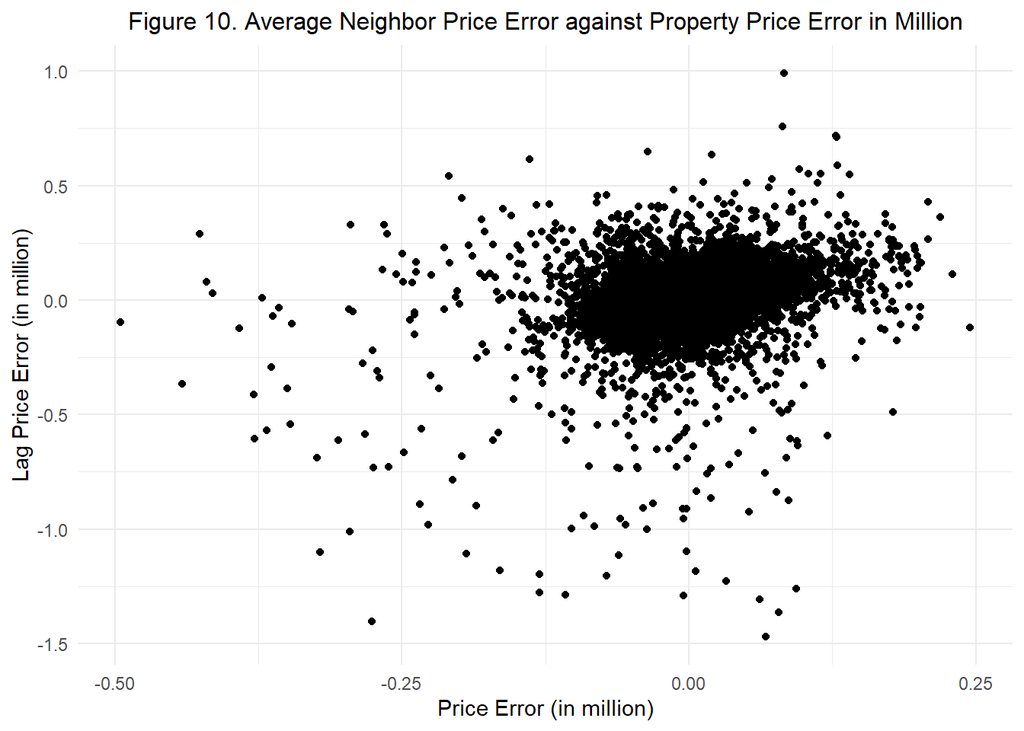

```r
final.kc.test <- final.kc.test %>%
  filter(is.finite(price.error))

final.coords.test <- st_coordinates(final.kc.test)

final.neighborList.test <- knn2nb(knearneigh(final.coords.test, 15))

final.spatialWeights.test <- nb2listw(final.neighborList.test, style="W")

final.kc.test <- final.kc.test %>%
  mutate(lagPrice.error = lag.listw(final.spatialWeights.test, price.error))

final.kc.test %>%
  as.data.frame() %>%
  ggplot() +
  geom_point(aes(x = lagPrice.error/1000000, y = price.error/1000000)) +
  labs(title="Figure 10. Average Neighbor Price Error against Property Price Error in Million",
        x = "Price Error (in million)",
        y = "Lag Price Error (in million)") +
  theme_minimal()+
  theme(plot.title = element_text(size = 12, hjust = 0.5))
```

The effectiveness of mitigated spatial autocorrelation is also confirmed through a Monte Carlo test involving 999 permutations conducted on the price error derived from the hedonic model. The resulting Global Moran’s I statistic for the price error is calculated as 0.108, with a p-value < 0.05. While this test continues to reveal statistically significant positive spatial autocorrelation, the impact within the enhanced model is notably reduced compared to the baseline model, where the Moran’s I for price error was 0.374 (see Technical Addendum, Section 3).

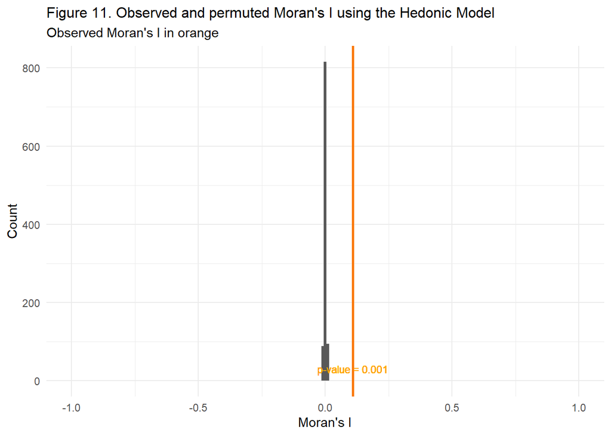

```r
moranTest.final <- moran.mc(final.kc.test$price.error,
                      final.spatialWeights.test, nsim = 999)

ggplot(as.data.frame(moranTest.final$res[c(1:999)]), aes(moranTest.final$res[c(1:999)])) +
  geom_histogram(binwidth = 0.01) +
  geom_vline(aes(xintercept = moranTest.final$statistic), colour = "#FA7800",size=1) +
  scale_x_continuous(limits = c(-1, 1)) +
  labs(title="Figure 11. Observed and permuted Moran's I using the Hedonic Model",
       subtitle= "Observed Moran's I in orange",
       x="Moran's I",
       y="Count") +
  theme_minimal() +
  geom_text(aes(x = moranTest.final$statistic, y = 30,
                label = paste("p-value =", signif(moranTest.final$p.value, digits = 4))),
            color = "orange", size = 3)+
  theme(plot.title = element_text(size = 12))
```

```r
moranTest.final$statistic
```

```
## statistic
## 0.1084222
```

### Additional Diagnostics

According to the following plot (fig.12) showing predicted sale price as a function of observed price for the final hedonic model, the predicted price-observed price pairs cluster tightly around the best-fit line, and the best-fit line predicts close to the line of perfect prediction. This signals that the hedonic model has high reliability.

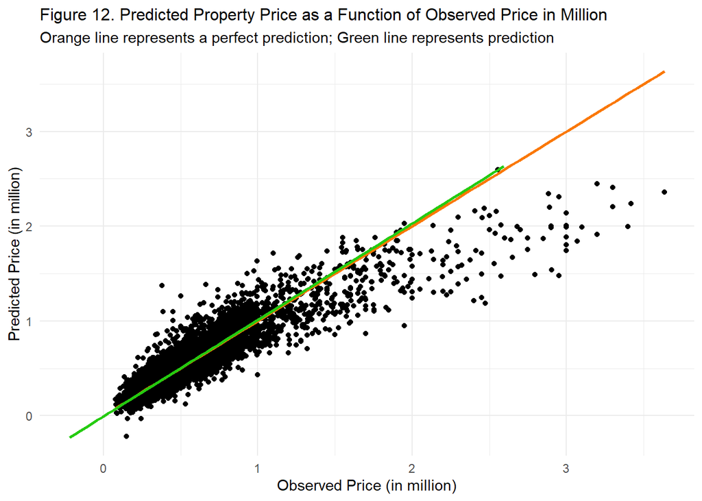

```r
options(scipen = 999)

final.kc.test %>%
  dplyr::select(price, price.pred) %>%
  ggplot(aes(price/1000000, price.pred/1000000)) +
  geom_point() +
  stat_smooth(aes(price/1000000, price/1000000),
              method = "lm", se = FALSE, size = 1, colour = "#FA7800") +
  stat_smooth(aes(price.pred/1000000, price/1000000),
              method = "lm", se = FALSE, size = 1, colour = "#25CB10") +
  labs(title = "Figure 12. Predicted Property Price as a Function of Observed Price in Million",
       subtitle = "Orange line represents a perfect prediction; Green line represents prediction",
       x = "Observed Price (in million)",
       y = "Predicted Price (in million)") +
  theme_minimal() +
  theme(plot.title = element_text(size = 12))
```

Additionally, I created maps to examine the spatial pattern of model errors by individual properties and properties within census tract. According to the first map showing model MAPE by individual properties across King County, percentage errors of different quintiles are generally randomly distributed across King County with no outstanding patterns of clustering.

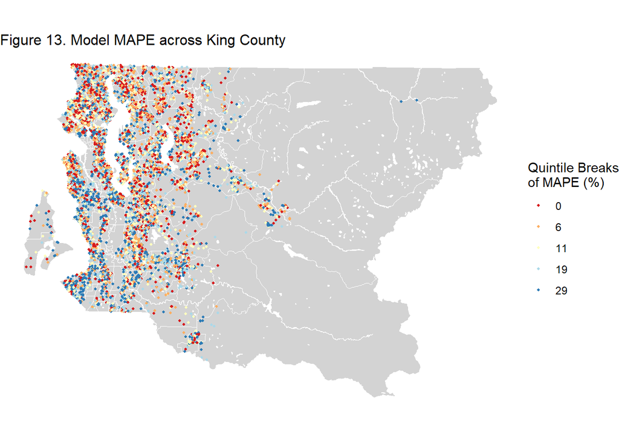

```r
final.kc.test$price.APE.percent <- final.kc.test$price.APE * 100

final.kc.test$quintiles <- ntile(final.kc.test$price.APE.percent, 5)

ggplot() +
  geom_sf(data = tracts15, fill = "lightgrey", col = "white")+
  geom_sf(data = final.kc.test, aes(colour = q5(price.APE.percent)),
          show.legend = "point", size = .75) +
  scale_colour_manual(values = palette5,
                   labels=qBr(final.kc.test, "price.APE.percent"), #how to show after .
                   name="Quintile Breaks\nof MAPE (%)") +
  labs(title= "Figure 13. Model MAPE across King County") +
  theme_void()+
  theme(plot.title = element_text(size = 12))
```

The second map further suggests that the hedonic model generally yields low MAPE values across census tracts, suggesting the model is relatively generalizable across the county. Nonetheless, the MAPE tends to be higher in census tracts with fewer or no observations, requiring additional data for improved inspection.

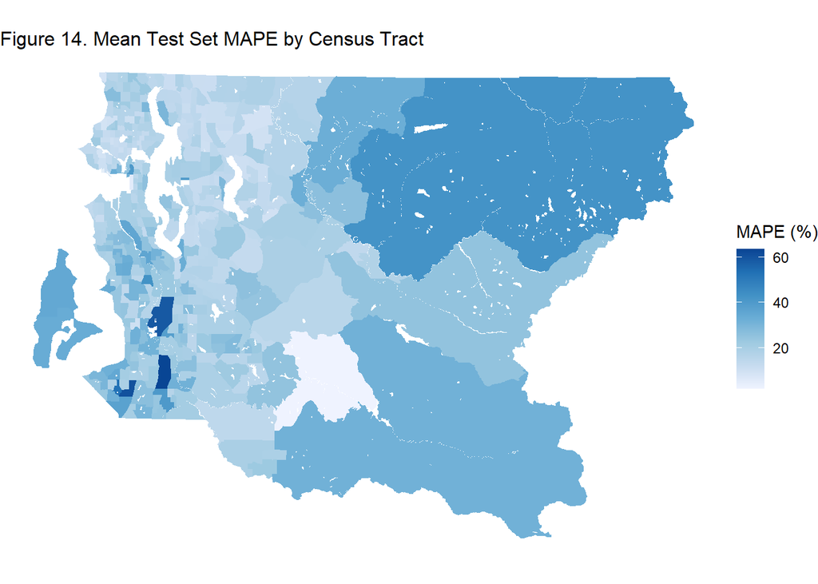

```r
invisible(capture.output({
CT.boundaries <-
  get_acs(geography = "tract",
          variables = c("B25026_001E"),
          year=2015, state=53,
          county=033, geometry=TRUE)%>%
  st_transform('EPSG:2926') %>%
  select(-variable, -estimate, -moe) %>%
  erase_water()
}))

final.kc.test.CT <- final.kc.test %>%
  st_join(CT.boundaries)

result <- st_drop_geometry(final.kc.test.CT) %>%
  group_by(Regression, NAME) %>%
  summarize(mean.MAPE = mean(price.APE.percent, na.rm = TRUE)) %>%
  ungroup() %>%
  left_join(CT.boundaries, by = "NAME") %>%
  st_sf()

ggplot() +
  geom_sf(data = result, aes(fill = mean.MAPE), col = NA) +
  scale_fill_distiller(palette = "Blues", direction = 1) +
  labs(title = "Figure 14. Mean Test Set MAPE by Census Tract", fill = "MAPE (%)") +
  theme_void()+
  theme(plot.title = element_text(size = 12))
```

## Conclusion

The final hedonic regression model is able to explain over 80% of variance in observations of King County’s single property prices at a statistically significant level. The prediction errors are subjected to relatively low spatial autocorrelation, and the model is mostly generalizable across census tracts county-wide.

Based on regression coefficient analysis, key factors of positive correlation to property values include square footage of internal living area, above-ground ratio, number of bathrooms, the existence of a waterfront, renovated condition, educational resources and traffic access. However, it’s important to note that not all spatial expansion contributes to positive growths in housing price, as evidenced by property with 3 bedrooms and above or 3 stories and above yielding decreasing values when all other conditions are equal. On the other hand, factors of negative correlation to property values include higher crime rates, enrollments per school, and distance to parks.Furthermore, racial profiles of a neighborhood also influence property values in King County, as observed in higher property values corresponding to neighborhoods with higher white population share.

Overall, the study provides key takeaways for real estate experts, including possible considerations of design, siting, amenity provision, and equity.

## Limitations

While the model demonstrates robust predictive capabilities for individual property values within King County, WA, it contains several limitations due to constraints of available data sources.

Firstly, the model’s accuracy may be compromised by the absence of observations in regions like Kent and Central Seattle. The missing property values, assuming induced by human error or a lack of recording, could make the model less generalizable.

Secondly, the aggregation of multiple independent variables, such as crime density, demographic factors, and all education-related factors, are conducted at varying spatial units.This variability in spatial aggregation can introduce inconsistencies and complicate the interpretation of results.

Lastly, the primary property value dataset used in the study was last compiled in 2015. While efforts were made to align other data sources with this time frame, certain datasets, such as crime data, are only available for later years, leading to temporal gaps between predictors and predictions. This discrepancy could potentially compromise the model’s predictability.

# Technical Addendum

## Section 1: Preliminary Correlation Testing

The following code performs a preliminary correlation matrix plot of all numeric variables from the original property price dataset. This step helps to eliminate weak price prediction factors.

```r
kc_house_data <- kc_house_data %>%
  filter(!price > 5000000) %>%
  filter(!bedrooms > 12)

pre_numericVars <- kc_house_data %>%
  select_if(is.numeric) %>%
  na.omit()

pre_correlation_matrix <- cor(pre_numericVars)

print(pre_correlation_matrix)
```

```
##                         id       price     bedrooms    bathrooms sqft_living
## id             1.000000000 -0.02147599  0.001888047  0.003965372 -0.01428625
## price         -0.021475987  1.00000000  0.316848740  0.522214606  0.69677456
## bedrooms       0.001888047  0.31684874  1.000000000  0.528088633  0.59226556
## bathrooms      0.003965372  0.52221461  0.528088633  1.000000000  0.75251347
## sqft_living   -0.014286247  0.69677456  0.592265565  0.752513466  1.00000000
## sqft_lot      -0.132213761  0.09125311  0.032548666  0.087491661  0.17357175
## floors         0.018260399  0.26176308  0.180468197  0.501197545  0.35483069
## waterfront    -0.003645630  0.25609783 -0.010120227  0.058152505  0.09468526
## view           0.010601967  0.39635791  0.079426308  0.182935500  0.27940451
## condition     -0.023695830  0.03866996  0.025552662 -0.125402743 -0.05891260
## grade          0.007312555  0.67635247  0.364818701  0.663002554  0.76244256
## sqft_above    -0.012633730  0.60103284  0.489671300  0.682291831  0.87495887
## sqft_basement -0.005887407  0.31538754  0.307644665  0.278738142  0.42957681
## yr_built       0.021411879  0.05578075  0.159213128  0.508245878  0.32126338
## yr_renovated  -0.017483368  0.12394707  0.018729927  0.048895453  0.05199328
## zipcode       -0.007996294 -0.05174356 -0.156761272 -0.203824510 -0.19977526
## lat           -0.001940248  0.31708400 -0.010892655  0.023911075  0.05180204
## long           0.020815268  0.02350020  0.134140881  0.224435944  0.24322456
## sqft_living15 -0.003795278  0.59492401  0.401334377  0.567087741  0.75781748
## sqft_lot15    -0.138972380  0.08361295  0.030100682  0.086841931  0.18411752
##                   sqft_lot       floors  waterfront         view    condition
## id            -0.132213761  0.018260399 -0.00364563  0.010601967 -0.023695830
## price          0.091253111  0.261763081  0.25609783  0.396357906  0.038669961
## bedrooms       0.032548666  0.180468197 -0.01012023  0.079426308  0.025552662
## bathrooms      0.087491661  0.501197545  0.05815251  0.182935500 -0.125402743
## sqft_living    0.173571750  0.354830690  0.09468526  0.279404506 -0.058912598
## sqft_lot       1.000000000 -0.005350113  0.02100268  0.074448861 -0.008889493
## floors        -0.005350113  1.000000000  0.02243258  0.028262810 -0.263762638
## waterfront     0.021002677  0.022432584  1.00000000  0.400198160  0.017004989
## view           0.074448861  0.028262810  0.40019816  1.000000000  0.046287425
## condition     -0.008889493 -0.263762638  0.01700499  0.046287425  1.000000000
## grade          0.113391366  0.458052239  0.07832779  0.248059329 -0.144799652
## sqft_above     0.183935158  0.525312053  0.06468711  0.161793150 -0.158813244
## sqft_basement  0.014757253 -0.248268921  0.07454047  0.274213691  0.174746284
## yr_built       0.053048868  0.489529700 -0.02671837 -0.054033560 -0.361345489
## yr_renovated   0.007484928  0.005767320  0.09152582  0.103185871 -0.060747098
## zipcode       -0.129486135 -0.058911448  0.03213270  0.085969867  0.002837227
## lat           -0.085758979  0.049495210 -0.01520609  0.005623052 -0.014985758
## long           0.229543942  0.125496029 -0.04233303 -0.078454513 -0.106412015
```

[output cut: 29 more lines]

```
## sqft_lot      -0.129486135 -0.085758979  0.22954394   0.144451249  0.718551301
## floors        -0.058911448  0.049495210  0.12549603   0.279304846 -0.011413698
## waterfront     0.032132704 -0.015206086 -0.04233303   0.082967618  0.030238436
## view           0.085969867  0.005623052 -0.07845451   0.277881573  0.072207648
## condition      0.002837227 -0.014985758 -0.10641201  -0.092712456 -0.003302806
## grade         -0.184458830  0.113780617  0.19910037   0.712279921  0.118984572
## sqft_above    -0.261550514 -0.001846141  0.34656446   0.731776133  0.194459319
## sqft_basement  0.075980396  0.110226724 -0.14496635   0.197383247  0.016868470
## yr_built      -0.346807182 -0.148168654  0.40938536   0.326481926  0.070849700
## yr_renovated   0.064603310  0.029208195 -0.06828754  -0.003793560  0.007816000
## zipcode        1.000000000  0.267213949 -0.56415196  -0.278722986 -0.147105333
## lat            0.267213949  1.000000000 -0.13546413   0.048519095 -0.086490170
## long          -0.564151964 -0.135464126  1.00000000   0.335247180  0.254467713
## sqft_living15 -0.278722986  0.048519095  0.33524718   1.000000000  0.183018844
## sqft_lot15    -0.147105333 -0.086490170  0.25446771   0.183018844  1.000000000
```

## Section 2: Data Gathering

The following section duplicates and breaks down the locational factor data gathering process from the report, and adds data sources to each category. Please note, all code for this section is intentionally voided to prevent conflict with the report.

### Transportation Data

Transportation data feeds into two categories: Access to Services and Amenities - Bus and Transit Buffer. The following code thus processed the transportation information in two approaches: - 1. The aggregated number of traditional bus stations located in a quarter-mile buffer around the house. - 2. Distinguish whether the property is located within a half-mile station buffer from Link, Sounder, and Express Bus stations. The additional “transit_buffer” is mutated to further determine if the property is located within a half-mile buffer to any of the three high speed commute assets mentioned.

Sources of data:

- “https://www.soundtransit.org/help-contacts/business-information/open-transit-data-otd/otd-downloads”
- “https://gis-kingcounty.opendata.arcgis.com/datasets/kingcounty::transit-stops-for-king-county-metro-transitstop-point/explore?location=47.644740%2C-122.132486%2C12.58”

```r
#Transit Buffer
#T.Link <- st_read("data/Transportation/STPublicData/LINKStations.shp") %>%
  #st_transform(crs = "EPSG:2926")
#T.Sounder <- st_read("data/Transportation/STPublicData/SNDRStations.shp") %>%
  #st_transform(crs = "EPSG:2926")
#T.Express <- st_read("data/Transportation/STPublicData/STExpStops.shp")%>%
  #st_transform(crs = "EPSG:2926")

#Link_Buffer <- st_union(st_buffer(T.Link, 2640))

#Sounder_Buffer <- st_union(st_buffer(T.Sounder, 2640))

#Express_Buffer <- st_union(st_buffer(T.Express, 2640))

#kc_house.sf <-
  #rbind(
      #kc_house.sf[Link_Buffer,] %>%
  #st_drop_geometry() %>%
  #mutate(link_buffer = "Y") %>%
  #select(id, link_buffer) %>%
    #left_join(kc_house.sf, by = "id") %>%
    #st_sf(),
      #kc_house.sf[Link_Buffer, op = st_disjoint] %>%
  #st_drop_geometry() %>%
  #mutate(link_buffer = "N") %>%
  #select(id, link_buffer) %>%
    #left_join(kc_house.sf, by = "id") %>%
    #st_sf())

#kc_house.sf <-
  #rbind(
      #kc_house.sf[Sounder_Buffer,] %>%
  #st_drop_geometry() %>%
  #mutate(sounder_buffer = "Y") %>%
  #select(id, sounder_buffer) %>%
    #left_join(kc_house.sf, by = "id") %>%
    #st_sf(),
      #kc_house.sf[Sounder_Buffer, op = st_disjoint] %>%
  #st_drop_geometry() %>%
  #mutate(sounder_buffer = "N") %>%
  #select(id, sounder_buffer) %>%
    #left_join(kc_house.sf, by = "id") %>%
    #st_sf())

#kc_house.sf <-
  #rbind(
      #kc_house.sf[Express_Buffer,] %>%
  #st_drop_geometry() %>%
  #mutate(express_buffer = "Y") %>%
  #select(id, express_buffer) %>%
    #left_join(kc_house.sf, by = "id") %>%
    #st_sf(),
      #kc_house.sf[Express_Buffer, op = st_disjoint] %>%
  #st_drop_geometry() %>%
  #mutate(express_buffer = "N") %>%
  #select(id, express_buffer) %>%
    #left_join(kc_house.sf, by = "id") %>%
    #st_sf())

#kc_house.sf <- kc_house.sf %>%
  #mutate(transit_buffer = if_else(express_buffer == "Y" | link_buffer == "Y" | sounder_buffer == "Y", "Y", "N"))

#Access to Services and Amenities - Bus Stops
#T.Bus <- st_read("data/Transportation/Bus Point KC/Transit_Stops_for_King_County_Metro___transitstop_point.shp")%>%
  #st_transform(crs = "EPSG:2926")

#buffers <- st_buffer(kc_house.sf$geometry, 1320)

#counts <- lengths(st_intersects(buffers, T.Bus))

#kc_house.sf$busbuffer <- counts
```

### Access to Services and Amenities - Medical Facilities

Access to Medical Facilities is measured as the average distance (ft) from the property to the nearest 1 medical facility including assets such as hospitals and clinics.

Source of data:

- “https://gis-kingcounty.opendata.arcgis.com/datasets/medical-facilities-including-hospitals-medical-facilities-point/explore?location=47.574135%2C-121.944606%2C10.00”

```r
#medical <- st_read("data/Medical_Facilities_including_Hospitals___medical_facilities_point/Medical_Facilities_including_Hospitals___medical_facilities_point.shp") %>%
  #st_transform(crs = "EPSG:2926")

#kc_house.sf <-
  #kc_house.sf %>%
  #mutate(
    #medical_nn1 = nn_function(st_coordinates(kc_house.sf),
                            #st_coordinates(medical), k = 1))
```

### Access to Services and Amenities - Education Resources

School enrollment in King County is determined by the resident’s school district rather than distance from schools. Based on school district, enrollment information between 2014 and 2015, and location of public schools, the following code aggregates a list of variables including schools.per.acre, enrollment.per.acre, enrollment.per.school, and pct.lowInc.students. Please note that the reference geographic unit of all the variables is school district.

Note: Data inspection suggests differing school district coding among datasets. Thus OrganizationId (shortened as Organizati) is identified and used as the unique identifier for each school district in following data manipulation.

Source of data:

- “https://geo.wa.gov/datasets/k12wa::washington-school-district-boundaries/explore?location=47.204588%2C-120.912772%2C7.23”
- “https://geo.wa.gov/datasets/k12wa::washington-state-public-schools/explore”
- “https://data.wa.gov/education/Report-Card-Enrollment-2014-15-School-Year/i9gq-g35m/about_data”

```r
#school.district <- st_read("data/Schools/Washington_School_District_Boundaries/Washington_School_District_Boundaries.shp") %>%
  #st_transform(crs = "EPSG:2926")

#school.district <- school.district %>%
  #mutate(area_sqft = st_area(school.district),
         #area_acres = area_sqft / 43560,
         #area_sqft = as.numeric(area_sqft), area_acres = as.numeric(area_acres))

#enrollment <- read.csv("data/Schools/Report_Card_Enrollment_2014-15_School_Year_20240305.csv")

#Allgrades.enrollment <- enrollment %>%
  #filter(County == "King" &
           #GradeLevel == "All Grades" &
           #SchoolName == "District Total") %>%
  #select(DistrictCode, DistrictName, DistrictOrganizationId, All.Students, Low.Income) %>%
  #mutate(DistrictOrganizationId = as.integer(DistrictOrganizationId))

#Allgrades.enrollment <- Allgrades.enrollment %>%
  #left_join(school.district, by = c("DistrictOrganizationId" = "Organizati"))

#pubschools <- st_read("data/Schools/Washington_State_Public_Schools_-1714177805432269700/Washington_State_Public_Schools.shp")%>%
  #st_transform(crs = "EPSG:2926")

#pubschools <- pubschools %>%
  #st_join(school.district) %>%
  #group_by(Organizati.y) %>%
  #tally() %>%
  #st_drop_geometry() %>%
  #mutate(TotalSchools = n)

#school.district.profile <- Allgrades.enrollment %>%
  #inner_join(pubschools, by = c("DistrictOrganizationId" = "Organizati.y"))

#school.district.profile <- school.district.profile %>%
  #mutate(schools.per.acre = TotalSchools / area_acres,
    #enrollment.per.acre = All.Students / area_acres,
    #enrollment.per.school = All.Students / TotalSchools,
    #pct.lowInc.students = (Low.Income / All.Students) * 100) %>%
  #select(schools.per.acre, enrollment.per.acre, enrollment.per.school, pct.lowInc.students, geometry)

#school.district.profile <- st_as_sf(school.district.profile)

#kc_house.sf <- kc_house.sf %>%
  #st_join(school.district.profile)
```

### Access to Services and Amenities - Parks

Access to green and open space is measured as the property’s average distance (ft) to the nearest 1 or 3 parks. Acknowledging that the parks have varying sizes and each would have multiple entry points, the park polygon shapefile is divided into quarter-mile grids to allow distances to be measured from the nuanced grid centroids to individual properties.

Source of data:

- “https://gis-kingcounty.opendata.arcgis.com/datasets/parks-in-king-county-park-area/explore?location=47.500420%2C-121.789744%2C9.33”

```r
#parks <- st_read("data/Parks_in_King_County___park_area/Parks_in_King_County___park_area.shp") %>%
  #st_transform(crs = "EPSG:2926")

#grid_parks <- st_make_grid(parks, cellsize = c(1320, 1320)) %>%
  #.[parks]

#parks.centroid <- st_centroid(grid_parks)

#kc_house.sf <-
  #kc_house.sf %>%
  #mutate(
    #parks_nn1 = nn_function(st_coordinates(kc_house.sf),
                              #st_coordinates(parks.centroid), k = 1),
    #parks_nn3 = nn_function(st_coordinates(kc_house.sf),
                              #st_coordinates(parks.centroid), k = 3))
```

### Risk - Crimes

King County’s data is zip code based rather than geospatial point-based. The following code calculates crime.density as crimes per acre for each zip code in King County, and matches the variable to properties located in the same zip code.

Source of data:

- “https://data.kingcounty.gov/Law-Enforcement-Safety/KCSO-Offense-Reports-2020-to-Present/4kmt-kfqf/about_data”
- “https://www2.census.gov/geo/tiger/TIGER2023/ZCTA520/”
- “https://gis-kingcounty.opendata.arcgis.com/datasets/19b7f1e85a0f4c9ebfcc2830bd1d783e_121/explore”

```r
#US_zip <- st_read("data/tl_2023_us_zcta520/tl_2023_us_zcta520.shp")
#kc_boundary <- st_read("data/King_County_Political_Boundary_(no_waterbodies)___kingco_area/") %>%
  #st_transform(crs = st_crs(US_zip))

#kc_zip <- st_intersection(US_zip, kc_boundary)

#kc_zip <- kc_zip %>%
  #mutate(Selection_Type = "Clip") %>%
  #mutate(area_sqft = st_area(kc_zip),
         #area_acres = area_sqft / 43560,
         #area_sqft = as.numeric(area_sqft), area_acres = as.numeric(area_acres))

#crime <- read.csv("data/Crime/KCSO_Offense_Reports__2020_to_Present_20240305.csv")

#crime$zip <- substr(crime$zip, 1, 5)

#crime.zip <- crime %>%
  #distinct(case_number, .keep_all = TRUE) %>%
  #group_by(zip) %>%
  #tally() %>%
  #mutate(n = as.numeric(n)) %>%
  #right_join(kc_zip, by = c("zip" = "ZCTA5CE20")) %>%
  #mutate(crime.density = n/area_acres) %>%
  #select(zip, crime.density)

#kc_house.sf <- kc_house.sf %>%
  #mutate(zipcode = as.character(zipcode)) %>%
  #left_join(crime.zip, by = c("zipcode" = "zip"))
```

### Risk - Flooding

King County’s proximity to a range of water bodies from Puget Sound to Lake Washington makes the region prone to flooding risks in the face of climate change. In addition to the common risk factor of crime, the study further hypothesizes the property’s average distance from the nearest flooding point as a value determining factor. Acknowledging that the flooding zones have varying sizes and each would have multiple risk points, the polygon shapefile is divided into quarter-mile grids to allow distances to be measured from the nuanced grid centroids to individual properties.

Source of data:

- “https://gis-kingcounty.opendata.arcgis.com/datasets/177ffad5de5e403b85da181e7e697497_2853/explore?location=47.448520%2C-122.051422%2C9.59”

```r
#flooding <- st_read("data/FEMA_High_Risk_Flood_Area_(100-year_Floodplain)___fema_floodplain_100yr_area/FEMA_High_Risk_Flood_Area_(100-year_Floodplain)___fema_floodplain_100yr_area.shp") %>%
  #st_transform(crs = "EPSG:2926")

#grid_flooding <- st_make_grid(flooding, cellsize = c(1320, 1320)) %>%
  #.[flooding]

#flooding.centroid <- st_centroid(grid_flooding)

#kc_house.sf <-
  #kc_house.sf %>%
  #mutate(
    #flooding_nn1 = nn_function(st_coordinates(kc_house.sf),
                              #st_coordinates(flooding.centroid), k = 1))
```

### Demographic Characteristics

Vast urban planning literature suggests that the condition of a neighborhood and property is usually related to its demographic characteristics, such as share of particular race, median household income, education level, and share of population below the poverty level. An account of these factors will improve the model’s sensitivity to equity related real estate pricing and planning.

Source of data: - American Community Survey 2015 retrieved using the tidycensus package.

```r
#tracts15 <-
  #get_acs(geography = "tract",
          #variables = c("B25026_001E","B02001_002E",
                        #"B15001_050E","B15001_009E",
                        #"B19013_001E",
                        #"B06012_002E"),
          #year=2015, state=53,
          #county=033, geometry=TRUE)%>%
  #st_transform('EPSG:2926')

#tracts15 <-
  #tracts15 %>%
  #dplyr::select( -NAME, -moe) %>%
  #spread(key = variable, value = estimate) %>%
  #rename(TotalPop = B25026_001,
         #Whites = B02001_002,
         #FemaleBachelors = B15001_050,
         #MaleBachelors = B15001_009,
         #MedHHInc = B19013_001,
         #TotalPoverty = B06012_002)

#tracts15 <-
  #tracts15 %>%
  #mutate(pctWhite = ifelse(TotalPop > 0, (Whites / TotalPop)*100, 0),
         #pctBachelors = ifelse(TotalPop > 0, ((FemaleBachelors + MaleBachelors) / TotalPop)*100, 0),
         #pctPoverty = ifelse(TotalPop > 0, (TotalPoverty / TotalPop)*100, 0),
         #year = "2015") %>%
  #dplyr::select(-Whites,-FemaleBachelors,-MaleBachelors,-TotalPoverty, -TotalPop, -GEOID, -year) %>%
  #erase_water()

#kc_house.sf <- st_join(kc_house.sf, tracts15, join = st_intersects)
```

## Section 3: Baseline Model Testing

### Preliminary Baseline Model Test

A preliminary baseline model test is first conducted by regressing property price against the maximum amount of hypothesized variables. Variables excluded in this step include tot_rooms due to perceived high multicollinearity with bedrooms and bathrooms, as well as nearest neighbor variables, including sqft_living15 and lag_price.

The preliminary baseline model accounts for 75.8% of the variation in the data (adjusted R-squared = 0.7579). The model predicts significantly better than the mean with F-stat (45, 21299) = 1485 (p-value < 0.05). However, the model contains multiple coefficients with poor statistical significance. For instance, most categories under “grade” yields no statistical significance at p<0.05 level, indicating this variable is highly correlated with other variables. The inclusion of such variables potentially results in multicollinearity.

```r
base.reg0 <- lm(price ~ bedrooms + bathrooms +
                sqft_living + sqft_above + sqft_basement +
                ratio_above + bldg_age +
                busbuffer + medical_nn1 + schools.per.acre +
                enrollment.per.school + pct.lowInc.students + crime.density +
                parks_nn1 + parks_nn3 + flooding_nn1 +
                MedHHInc + pctWhite + pctBachelors + pctPoverty +
                floors + if_single + if_basement + bedrooms_lvl+
                grade + waterfront + if_renovated +
                link_buffer + sounder_buffer + express_buffer + transit_buffer,
                data = kc_house.sf)

options(scipen = 0)

base.reg0_summary <- summary(base.reg0)

base.reg0_coef <- as.data.frame(base.reg0_summary$coefficients) %>%
  mutate(significance = if_else(`Pr(>|t|)` < 0.001, '***',
                                if_else(`Pr(>|t|)` < 0.01, '**',
                                        if_else(`Pr(>|t|)` < 0.05, '*',
                                             if_else(`Pr(>|t|)` < 0.1, '.', '')))),
         p_value = paste0(`Pr(>|t|)`, significance)) %>%
  select(-significance, -`Pr(>|t|)`) %>%
  kable(caption = "Preliminary Baseline Model Coefficients", align = "r") %>%
  kable_material(c("striped", "hover"))
base.reg0_coef
```

Preliminary Baseline Model Coefficients

|  | Estimate | Std. Error | t value | p_value |
| --- | --- | --- | --- | --- |
| (Intercept) | -6.958563e+05 | 1.045528e+05 | -6.6555495 | 2.89107395494119e-11*** |
| bedrooms | -2.244601e+04 | 2.893798e+03 | -7.7565907 | 9.11497840915613e-15*** |
| bathrooms | 3.866867e+04 | 2.879459e+03 | 13.4291440 | 5.99037943755621e-41*** |
| sqft_living | 2.616869e+02 | 7.946605e+00 | 32.9306480 | 5.16338397860774e-232*** |
| sqft_above | -1.291845e+02 | 8.850072e+00 | -14.5969952 | 5.00795627235546e-48*** |
| ratio_above | 5.151454e+03 | 2.678419e+02 | 19.2331900 | 9.63550761062042e-82*** |
| bldg_age | 1.924258e+03 | 6.663919e+01 | 28.8757700 | 6.97982811326358e-180*** |
| busbuffer | 1.264658e+03 | 7.804437e+01 | 16.2043433 | 1.05499988518903e-58*** |
| medical_nn1 | -5.392492e-01 | 2.224128e-01 | -2.4245414 | 0.0153359980887185* |
| schools.per.acre | 1.296545e+08 | 4.432986e+06 | 29.2476585 | 2.10771439508055e-184*** |
| enrollment.per.school | -2.574777e+01 | 1.547952e+01 | -1.6633447 | 0.0962581769505415. |
| pct.lowInc.students | -3.058102e+03 | 9.364938e+01 | -32.6547997 | 2.85848459654914e-228*** |
| crime.density | -4.061416e+03 | 3.255579e+02 | -12.4752468 | 1.35699863784878e-35*** |
| parks_nn1 | 4.203079e+00 | 3.919332e+00 | 1.0723966 | 0.283554081206506 |
| parks_nn3 | -2.276450e+01 | 4.008021e+00 | -5.6797370 | 1.36660382508771e-08*** |
| flooding_nn1 | 5.097647e+00 | 3.783813e-01 | 13.4722482 | 3.36057784442708e-41*** |
| MedHHInc | 1.846513e+00 | 5.964030e-02 | 30.9608257 | 6.55890584690106e-206*** |
| pctWhite | 1.879154e+03 | 9.690114e+01 | 19.3924876 | 4.64799942686055e-83*** |
| pctBachelors | 1.044666e+04 | 9.503691e+02 | 10.9922168 | 4.95508432951315e-28*** |
| pctPoverty | 1.329074e+03 | 2.619804e+02 | 5.0731828 | 3.94502100782184e-07*** |
| floors1.5 | -8.922258e+03 | 4.801158e+03 | -1.8583554 | 0.0631323416541992. |
| floors2 | -2.282895e+04 | 3.903042e+03 | -5.8490157 | 5.0172072090577e-09*** |
| floors2.5 | 6.496773e+04 | 1.429726e+04 | 4.5440696 | 5.54814931152145e-06*** |
| floors3 | 4.381951e+03 | 8.602945e+03 | 0.5093548 | 0.610508841478264 |
| floors3.5 | 6.451465e+04 | 6.572621e+04 | 0.9815666 | 0.326324555273751 |
| if_basementY | 7.100781e+04 | 5.969567e+03 | 11.8949688 | 1.59356533858308e-32*** |
| bedrooms_lvlL2 | 3.824605e+04 | 1.352665e+04 | 2.8274595 | 0.00469626960169077** |
| bedrooms_lvlL3 | 4.529562e+04 | 1.453211e+04 | 3.1169337 | 0.00182985725458363** |
| bedrooms_lvlL4 | 6.356759e+04 | 1.747767e+04 | 3.6370750 | 0.000276402164761009*** |
| bedrooms_lvlL5 | 3.655272e+04 | 9.106768e+04 | 0.4013797 | 0.688144623600402 |
| grade4 | -1.580755e+05 | 1.056748e+05 | -1.4958680 | 0.134702870411814 |
| grade5 | -1.428385e+05 | 1.012498e+05 | -1.4107542 | 0.158331717683345 |
| grade6 | -1.306905e+05 | 1.008770e+05 | -1.2955426 | 0.19514715055624 |
| grade7 | -1.012984e+05 | 1.009053e+05 | -1.0038957 | 0.315440278887414 |
| grade8 | -5.262179e+04 | 1.009742e+05 | -0.5211412 | 0.602273853235383 |
| grade9 | 6.403789e+04 | 1.010779e+05 | 0.6335497 | 0.526381536882001 |
| grade10 | 2.125059e+05 | 1.012519e+05 | 2.0987835 | 0.0358477312791347* |
| grade11 | 4.581420e+05 | 1.016642e+05 | 4.5064253 | 6.62796244929818e-06*** |
| grade12 | 8.849503e+05 | 1.032620e+05 | 8.5699505 | 1.10469063837037e-17*** |
| grade13 | 1.355237e+06 | 1.156676e+05 | 11.7166518 | 1.30953908735152e-31*** |
| waterfront1 | 7.141671e+05 | 1.454251e+04 | 49.1089197 | 0*** |
| if_renovatedY | 4.762097e+04 | 6.249536e+03 | 7.6199203 | 2.64416267389147e-14*** |
| link_bufferY | -8.165101e+02 | 1.114462e+04 | -0.0732650 | 0.941595943233725 |
| sounder_bufferY | -1.118664e+05 | 3.181614e+04 | -3.5160263 | 0.000438968137425184*** |
| express_bufferY | 3.185540e+04 | 1.308872e+04 | 2.4338058 | 0.0149491717202042* |
| transit_bufferY | -6.890489e+03 | 1.381144e+04 | -0.4988970 | 0.617857076594284 |

```r
base.reg0_fit <- data.frame(
  Statistic = c("Multiple R-squared", "Adjusted R-squared", "F-statistic"),
  Value = c(
    base.reg0_summary$r.squared,
    base.reg0_summary$adj.r.squared,
    base.reg0_summary$fstatistic[1])) %>%
  kable(caption = "Preliminary Baseline Model Statistics", align = "r", format = "html") %>%
  kable_material(c("striped", "hover"))
base.reg0_fit
```

Preliminary Baseline Model Statistics

| Statistic | Value |
| --- | --- |
| Multiple R-squared | 0.7583678 |
| Adjusted R-squared | 0.7578573 |
| F-statistic | 1485.4971979 |

### Improved Baseline Model

After observations and testing, the final baseline model is improved using the code below. Key modifications include:

- Variable bedroom_lvl is used as a better alternative to bedrooms, since it accounts for structure-based lags, while maintaining independence from bathrooms.
- Variable If_basement is removed, due to whether a house contains a basement can be accounted for using ratio_above. Grade is removed due to high multicollinearity with multiple variables.
- Variable park_nn3 is selected over park_nn1 to account for more comprehensive environmental quality and land use pattern.
- Variable transit_buffer is retained over all three individual high-speed transit station buffers.
- An interaction term, schools.per.acre * enrollment.per.school, is added to include the effects of school density on enrollment levels.

The final baseline model accounts for 70.3% of the variation in the data (adjusted R-squared = 0.7032). The model predicts significantly better than the mean with F-stat (29, 21315) = 1744 (p-value < 0.05). Despite a marginal 5% decrease in model fit compared to the unimproved baseline model, the final baseline model better satisfies the assumption of no multicollinearity, as shown in the VIF test where all variables except for schools.per.acre is successfully controlled below the threshold of 4. The variable schools.per.acre’s GVIF value is inevitably inflated due to the interaction term.

```r
base.reg1 <- lm(price ~ sqft_living +
                  bedrooms_lvl + bathrooms +
                  ratio_above + bldg_age +
                  waterfront + floors +
                  if_renovated +
                  medical_nn1 +
                  schools.per.acre + enrollment.per.school + pct.lowInc.students +
                  schools.per.acre*enrollment.per.school +
                  crime.density +
                  parks_nn3 + flooding_nn1 +
                  MedHHInc + pctWhite + pctBachelors + pctPoverty +
                  busbuffer +
                  transit_buffer,
                data = dplyr::select(kc_house.sf, -geometry))

base.reg1_summary <- summary(base.reg1)

base.reg1_coef <- as.data.frame(base.reg1_summary$coefficients) %>%
  mutate(significance = if_else(`Pr(>|t|)` < 0.001, '***',
                                if_else(`Pr(>|t|)` < 0.01, '**',
                                        if_else(`Pr(>|t|)` < 0.05, '*',
                                             if_else(`Pr(>|t|)` < 0.1, '.', '')))),
         p_value = paste0(`Pr(>|t|)`, significance)) %>%
  select(-significance, -`Pr(>|t|)`) %>%
  kable(caption = "Improved Baseline Model Coefficients", align = "r") %>%
  kable_material(c("striped", "hover"))
base.reg1_coef
```

Improved Baseline Model Coefficients

|  | Estimate | Std. Error | t value | p_value |
| --- | --- | --- | --- | --- |
| (Intercept) | -5.510521e+05 | 2.704481e+04 | -20.3755266 | 2.04831527276001e-91*** |
| sqft_living | 2.534797e+02 | 2.505001e+00 | 101.1894470 | 0*** |
| bedrooms_lvlL2 | -7.585027e+03 | 1.428532e+04 | -0.5309667 | 0.595447391186969 |
| bedrooms_lvlL3 | -7.438019e+04 | 1.410621e+04 | -5.2728680 | 1.35617475908272e-07*** |
| bedrooms_lvlL4 | -1.296681e+05 | 1.507466e+04 | -8.6017254 | 8.38659113944459e-18*** |
| bedrooms_lvlL5 | -3.654366e+05 | 9.697572e+04 | -3.7683306 | 0.000164785600780649*** |
| bathrooms | 4.593472e+04 | 3.144142e+03 | 14.6096194 | 4.16723345881174e-48*** |
| ratio_above | 1.913863e+03 | 9.621028e+01 | 19.8925053 | 2.92628393066888e-87*** |
| bldg_age | 1.695690e+03 | 7.095499e+01 | 23.8981083 | 1.39281093558121e-124*** |
| waterfront1 | 7.823140e+05 | 1.602803e+04 | 48.8091044 | 0*** |
| floors1.5 | -2.378306e+04 | 5.283732e+03 | -4.5011859 | 6.79330074551876e-06*** |
| floors2 | -3.779436e+04 | 4.228627e+03 | -8.9377386 | 4.28802726304469e-19*** |
| floors2.5 | 8.858754e+04 | 1.574250e+04 | 5.6272865 | 1.85365952065902e-08*** |
| floors3 | 2.654742e+04 | 9.471814e+03 | 2.8027805 | 0.00507098709142343** |
| floors3.5 | 1.021807e+05 | 7.268616e+04 | 1.4057787 | 0.15980442988682 |
| if_renovatedY | 4.080375e+04 | 6.891436e+03 | 5.9209358 | 3.25021505321181e-09*** |
| medical_nn1 | -6.108019e-01 | 2.482514e-01 | -2.4604172 | 0.0138854330722152* |
| schools.per.acre | -9.094701e+07 | 1.726941e+07 | -5.2663648 | 1.40501668056423e-07*** |
| enrollment.per.school | -2.700786e+02 | 2.482721e+01 | -10.8783301 | 1.72689181897552e-27*** |
| pct.lowInc.students | -3.566627e+03 | 1.040558e+02 | -34.2760912 | 1.11010833587631e-250*** |
| crime.density | -3.201741e+03 | 3.674526e+02 | -8.7133443 | 3.1618294818842e-18*** |
| parks_nn3 | -2.497626e+01 | 1.369020e+00 | -18.2438941 | 8.43650548955758e-74*** |
| flooding_nn1 | 6.054057e+00 | 4.202579e-01 | 14.4055757 | 7.92246675050378e-47*** |
| MedHHInc | 2.209711e+00 | 6.524280e-02 | 33.8690418 | 5.78724522775654e-245*** |
| pctWhite | 2.162511e+03 | 1.055767e+02 | 20.4828448 | 2.37300446191061e-92*** |
| pctBachelors | 1.382016e+04 | 1.026853e+03 | 13.4587556 | 4.02674186662143e-41*** |
| pctPoverty | 2.032264e+03 | 2.879157e+02 | 7.0585389 | 1.73426084207494e-12*** |
| busbuffer | 1.523453e+03 | 8.534232e+01 | 17.8510895 | 9.28637122661658e-71*** |
| transit_bufferY | 1.273041e+04 | 4.362857e+03 | 2.9179076 | 0.00352756803342029** |
| schools.per.acre:enrollment.per.school | 5.020142e+05 | 3.388523e+04 | 14.8151327 | 2.06049206039442e-49*** |

```r
base.reg1_fit <- data.frame(
  Statistic = c("Multiple R-squared", "Adjusted R-squared", "F-statistic"),
  Value = c(
    base.reg1_summary$r.squared,
    base.reg1_summary$adj.r.squared,
    base.reg1_summary$fstatistic[1])) %>%
  kable(caption = "Improved Baseline Model Statistics", align = "r", format = "html") %>%
  kable_material(c("striped", "hover"))
base.reg1_fit
```

Improved Baseline Model Statistics

| Statistic | Value |
| --- | --- |
| Multiple R-squared | 0.7035628 |
| Adjusted R-squared | 0.7031594 |
| F-statistic | 1744.4455029 |

```r
vif.base.reg1_table <- as.data.frame(vif(base.reg1))
vif.base.reg1_table %>%
  kable(caption = "VIF Test Result of Improved Baseline Model", align = "r") %>%
  kable_material(c("striped", "hover"))
```

VIF Test Result of Improved Baseline Model

|  | GVIF | Df | GVIF^(1/(2*Df)) |
| --- | --- | --- | --- |
| sqft_living | 3.016335 | 1 | 1.736760 |
| bedrooms_lvl | 1.501275 | 4 | 1.052101 |
| bathrooms | 3.370619 | 1 | 1.835924 |
| ratio_above | 1.573238 | 1 | 1.254288 |
| bldg_age | 2.530130 | 1 | 1.590638 |
| waterfront | 1.035678 | 1 | 1.017683 |
| floors | 3.522357 | 5 | 1.134184 |
| if_renovated | 1.121432 | 1 | 1.058977 |
| medical_nn1 | 1.510805 | 1 | 1.229148 |
| schools.per.acre | 32.329549 | 1 | 5.685908 |
| enrollment.per.school | 3.239223 | 1 | 1.799784 |
| pct.lowInc.students | 2.233573 | 1 | 1.494514 |
| crime.density | 1.313335 | 1 | 1.146008 |
| parks_nn3 | 1.144775 | 1 | 1.069942 |
| flooding_nn1 | 1.215993 | 1 | 1.102720 |
| MedHHInc | 2.480640 | 1 | 1.575005 |
| pctWhite | 1.664378 | 1 | 1.290108 |
| pctBachelors | 1.439685 | 1 | 1.199869 |
| pctPoverty | 2.250928 | 1 | 1.500309 |
| busbuffer | 1.854948 | 1 | 1.361965 |
| transit_buffer | 1.125608 | 1 | 1.060947 |
| schools.per.acre:enrollment.per.school | 25.998496 | 1 | 5.098872 |

### Baseline Model General Diagnostics

Using the same test and training sets as the final hedonic model, the improved baseline model yields a 121,890.5 MAE and a 25.0% MAPE.

```r
base.kc.training <- kc_house.sf[inTrain,]

base.kc.test <- kc_house.sf[-inTrain,]

base.reg.training <- lm(price ~ .,
                        data = as.data.frame(base.kc.training) %>%
                        mutate(interaction = schools.per.acre * enrollment.per.school) %>%
                             dplyr::select(price, sqft_living,
                              bedrooms_lvl, bathrooms,
                              ratio_above, bldg_age,
                              waterfront, floors,
                              if_renovated,
                              medical_nn1,
                              schools.per.acre, enrollment.per.school, pct.lowInc.students,
                              interaction,
                              crime.density,
                              parks_nn3, flooding_nn1,
                              MedHHInc, pctWhite, pctBachelors, pctPoverty,
                              busbuffer,
                              transit_buffer))

base.kc.test <- base.kc.test %>% mutate(interaction = schools.per.acre * enrollment.per.school)

base.kc.test <-
  base.kc.test %>%
  mutate(Regression = "Baseline Regression",
         price.pred = predict(base.reg.training, base.kc.test),
         price.error = price.pred - price,
         price.Abs.error = abs(price.pred - price),
         price.APE = (abs(price.pred - price)) / price)

base.kc.test.table <- data.frame(
  Statistic = c("MAE", "MAPE"),
  Value = c(
    round(mean(base.kc.test$price.Abs.error, na.rm = TRUE), 2),
    sprintf("%.2f%%", round(mean(base.kc.test$price.APE, na.rm = TRUE) * 100, 2))
  ))

base.kc.test.table %>%
  kable(caption = "Baseline Model Diagnostic Stats", align = "r", format = "html") %>%
  kable_material("striped", "hover")
```

Baseline Model Diagnostic Stats

| Statistic | Value |
| --- | --- |
| MAE | 121890.47 |
| MAPE | 24.96% |

### Cross-Validation

The baseline model’s performance is further tested using a 100-fold cross-validation. Overall, the test reports an average Mean Absolute Error (MAE) of 123,807.1 and an average Root Mean Squared Error (RMSE) of 190,182.4 across all folds. The average R-squared is 0.707, indicating that on average, a 70.7% of variance in observations is captured by the model.

```r
set.seed(301)

base.cv <- train(price ~ .,
                data = kc_house.cv %>%
                        mutate(interaction = schools.per.acre * enrollment.per.school) %>%
                        select(price, sqft_living, bedrooms_lvl, bathrooms,
                              ratio_above, bldg_age,
                              waterfront, floors,
                              if_renovated,
                              medical_nn1,
                              schools.per.acre, enrollment.per.school, pct.lowInc.students,
                              interaction,
                              crime.density,
                              parks_nn3, flooding_nn1,
                              MedHHInc, pctWhite, pctBachelors, pctPoverty,
                              busbuffer,
                              transit_buffer),
                 method = "lm",
                 trControl = fitControl,
                 na.action = na.pass)

resample.base.cv <- base.cv$resample[, ] %>%
  summarise(Mean_MAE = round(mean(MAE), digits = 2),
            Mean_RMSE = round(mean(RMSE), digits = 2),
            Mean_Rsquared = round(mean(Rsquared), digits = 4),
            )

resample.base.cv.table <-
  as.data.frame(resample.base.cv) %>%
  kable(caption = "Improved Baseline Model Cross-Validation Stats", align = "r", format = "html") %>%
  kable_material(c("striped", "hover"))

resample.base.cv.table
```

Improved Baseline Model Cross-Validation Stats

| Mean_MAE | Mean_RMSE | Mean_Rsquared |
| --- | --- | --- |
| 123807.1 | 190182.4 | 0.7073 |

### Baseline Model Spatial Autocorrelation Check

Although the improved baseline model incorporates a significant amount of locational factors, most of them are aggregated at relatively large spatial levels (census tract, zip code, school district) due to limited data availability. Therefore, patterns of spatial autocorrelation in the model training results are further examined.

The following plot suggests evident pattern of clustering between price error of the property and its 15 neighbors, indicating relatively high spatial autocorrelation.

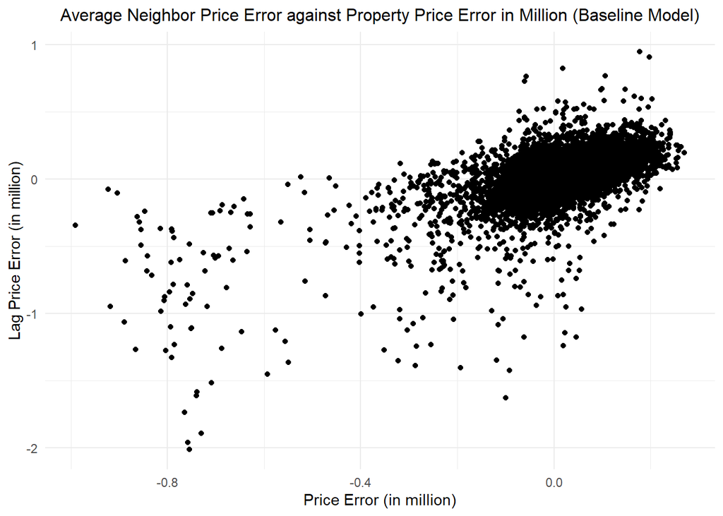

```r
base.kc.test <- base.kc.test %>%
  filter(is.finite(price.error))

base.coords.test <- st_coordinates(base.kc.test)

base.neighborList.test <- knn2nb(knearneigh(final.coords.test, 15))

base.spatialWeights.test <- nb2listw(base.neighborList.test, style="W")

base.kc.test <- base.kc.test %>%
  mutate(lagPrice.error = lag.listw(base.spatialWeights.test, price.error))

base.kc.test %>%
  as.data.frame() %>%
  ggplot() +
  geom_point(aes(x = lagPrice.error/1000000, y = price.error/1000000)) +
  labs(title="Average Neighbor Price Error against Property Price Error in Million (Baseline Model)",
        x = "Price Error (in million)",
        y = "Lag Price Error (in million)") +
  theme_minimal()+
  theme(plot.title = element_text(size = 12, hjust = 0.5))
```

A Monte Carlo test for spatial autocorrelation based on Global Moran’s I statistic of the price error is further calculated by running 999 permutations. The test yielded a Moran’s I of 0.374, which signals positive spatial autocorrelation, that nearby observations tend to have similar values. The test also yields a p-value of 0.001, which is below the significance level of p-value < 0.05, which confirms that the spatial autocorrelation is statistically significant among baseline model predictions.

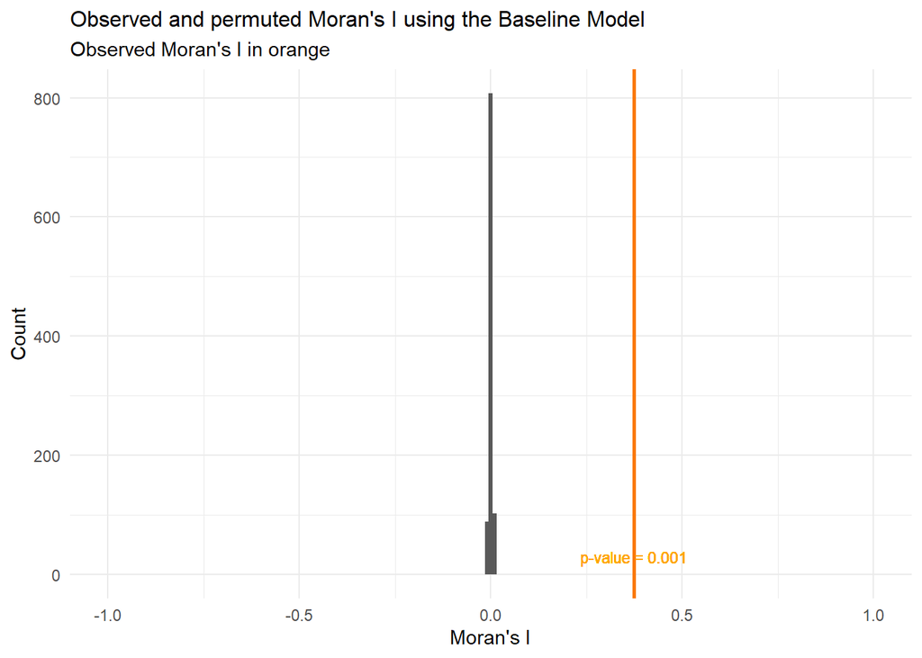

```r
moranTest.base <- moran.mc(base.kc.test$price.error,
                      base.spatialWeights.test, nsim = 999)

ggplot(as.data.frame(moranTest.base$res[c(1:999)]), aes(moranTest.base$res[c(1:999)])) +
  geom_histogram(binwidth = 0.01) +
  geom_vline(aes(xintercept = moranTest.base$statistic), colour = "#FA7800",size=1) +
  scale_x_continuous(limits = c(-1, 1)) +
  labs(title="Observed and permuted Moran's I using the Baseline Model",
       subtitle= "Observed Moran's I in orange",
       x="Moran's I",
       y="Count") +
  theme_minimal() +
  geom_text(aes(x = moranTest.base$statistic, y = 30,
                label = paste("p-value =", signif(moranTest.base$p.value, digits = 4))),
            color = "orange", size = 3)+
  theme(plot.title = element_text(size = 12))
```

```r
moranTest.base$statistic
```

```
## statistic
## 0.3741388
```

### Preliminary Test of Model Accounting for Spatial Lag

As the existence of significant spatial autocorrelation is confirmed by the correlation plot and Monte Carlo test above, additional neighborhood factors are required to improve model performance.

Compared with the final baseline model’s 70.4% model-fit, the preliminary improved model yields a better model-fit of 80.7% (adjusted R-squared = 0.8074), suggesting evident improvement. However, according to the VIF test results, the GVIF value of “sqft_living” variable of the preliminary improved model exceeds the threshold of 4. This is highly likely due to correlation between one property’s size and its neighbor property’s size.

From these observations, the model shown here is further improved to obtain the final hedonic model presented in the Main Report. Please kindly refer back to the Section “Hedonic Model” for subsequent analysis.

```r
improved.reg0 <- lm(price ~ sqft_living +
                     lag_price + sqft_living15 +
                     bedrooms_lvl + bathrooms +
                     ratio_above + bldg_age +
                     waterfront + floors +
                     if_renovated +
                  medical_nn1 +
                  schools.per.acre + enrollment.per.school + pct.lowInc.students +
                  schools.per.acre*enrollment.per.school +
                  crime.density +
                  parks_nn3 + flooding_nn1 +
                  MedHHInc + pctWhite + pctBachelors + pctPoverty +
                  busbuffer +
                  transit_buffer,
                data = dplyr::select(kc_house.sf, -geometry))

improved.reg0_summary <- summary(improved.reg0)

improved.reg0_coef <- as.data.frame(improved.reg0_summary$coefficients) %>%
  mutate(significance = if_else(`Pr(>|t|)` < 0.001, '***',
                                if_else(`Pr(>|t|)` < 0.01, '**',
                                        if_else(`Pr(>|t|)` < 0.05, '*',
                                             if_else(`Pr(>|t|)` < 0.1, '.', '')))),
         p_value = paste0(`Pr(>|t|)`, significance)) %>%
  select(-significance, -`Pr(>|t|)`) %>%
  kable(caption = "Preliminary Improved Model Coefficients", align = "r") %>%
  kable_material(c("striped", "hover"))
improved.reg0_coef
```

Preliminary Improved Model Coefficients

|  | Estimate | Std. Error | t value | p_value |
| --- | --- | --- | --- | --- |
| (Intercept) | -4.432950e+05 | 2.186875e+04 | -20.2707001 | 1.66454909262576e-90*** |
| sqft_living | 2.093651e+02 | 2.443471e+00 | 85.6834592 | 0*** |
| lag_price | 7.136798e-01 | 6.767300e-03 | 105.4599607 | 0*** |
| sqft_living15 | -3.670607e+01 | 2.814417e+00 | -13.0421565 | 9.91130817862254e-39*** |
| bedrooms_lvlL2 | -4.854695e+03 | 1.151260e+04 | -0.4216854 | 0.673258911240236 |
| bedrooms_lvlL3 | -3.800703e+04 | 1.137327e+04 | -3.3417871 | 0.000833839916909965*** |
| bedrooms_lvlL4 | -7.227757e+04 | 1.217034e+04 | -5.9388285 | 2.91518748890631e-09*** |
| bedrooms_lvlL5 | -2.581094e+05 | 7.813571e+04 | -3.3033478 | 0.000956951518138676*** |
| bathrooms | 3.167343e+04 | 2.536851e+03 | 12.4853340 | 1.1964014311725e-35*** |
| ratio_above | 1.786354e+03 | 7.803886e+01 | 22.8905704 | 1.38814875091266e-114*** |
| bldg_age | 3.262827e+02 | 5.864006e+01 | 5.5641607 | 2.66583603731942e-08*** |
| waterfront1 | 7.083333e+05 | 1.293086e+04 | 54.7785185 | 0*** |
| floors1.5 | -1.698217e+04 | 4.258958e+03 | -3.9874007 | 6.70238820077545e-05*** |
| floors2 | -4.002927e+04 | 3.406194e+03 | -11.7519050 | 8.65516207947124e-32*** |
| floors2.5 | 4.447596e+04 | 1.269702e+04 | 3.5028663 | 0.000461223148611733*** |
| floors3 | -2.881746e+04 | 7.666534e+03 | -3.7588642 | 0.000171141871247096*** |
| floors3.5 | 7.907187e+04 | 5.854892e+04 | 1.3505265 | 0.176861506480866 |
| if_renovatedY | 2.950501e+04 | 5.558348e+03 | 5.3082333 | 1.11800495301738e-07*** |
| medical_nn1 | -9.748142e-01 | 1.999780e-01 | -4.8746078 | 1.09808983502958e-06*** |
| schools.per.acre | 1.946194e+07 | 1.394792e+07 | 1.3953296 | 0.162931015001539 |
| enrollment.per.school | -1.133820e+02 | 2.007304e+01 | -5.6484693 | 1.6394640594691e-08*** |
| pct.lowInc.students | -6.732680e+02 | 8.803364e+01 | -7.6478491 | 2.13010592898721e-14*** |
| crime.density | -1.101429e+03 | 2.966025e+02 | -3.7134850 | 0.000204945627342081*** |
| parks_nn3 | -7.469620e+00 | 1.114624e+00 | -6.7014678 | 2.1148930368331e-11*** |
| flooding_nn1 | 2.976425e+00 | 3.398378e-01 | 8.7583715 | 2.12591139547553e-18*** |
| MedHHInc | -1.654254e-01 | 5.757870e-02 | -2.8730320 | 0.00406954341504077** |
| pctWhite | 1.061288e+03 | 8.597893e+01 | 12.3435867 | 6.94202005388997e-35*** |
| pctBachelors | 1.038273e+03 | 8.364410e+02 | 1.2412985 | 0.214509155712784 |
| pctPoverty | 7.356212e+02 | 2.323159e+02 | 3.1664692 | 0.00154519077892293** |
| busbuffer | 9.707371e+02 | 7.007854e+01 | 13.8521294 | 1.90563143413128e-43*** |
| transit_bufferY | 1.526084e+03 | 3.516274e+03 | 0.4340059 | 0.664288529199514 |
| schools.per.acre:enrollment.per.school | 6.020664e+04 | 2.760115e+04 | 2.1813086 | 0.0291714862000719* |

```r
improved.reg0_fit <- data.frame(
  Statistic = c("Multiple R-squared", "Adjusted R-squared", "F-statistic"),
  Value = c(
    improved.reg0_summary$r.squared,
    improved.reg0_summary$adj.r.squared,
    improved.reg0_summary$fstatistic[1])) %>%
  kable(caption = "Preliminary Improved Model Statistics", align = "r", format = "html") %>%
  kable_material(c("striped", "hover"))
improved.reg0_fit
```

Preliminary Improved Model Statistics

| Statistic | Value |
| --- | --- |
| Multiple R-squared | 0.8077138 |
| Adjusted R-squared | 0.8074341 |
| F-statistic | 2887.9666708 |

```r
improved.reg0_table <- as.data.frame(vif(improved.reg0))
improved.reg0_table %>%
  kable(caption = "VIF Test Result of Preliminary Improved Model", align = "r") %>%
  kable_material(c("striped", "hover"))
```

VIF Test Result of Preliminary Improved Model

|  | GVIF | Df | GVIF^(1/(2*Df)) |
| --- | --- | --- | --- |
| sqft_living | 4.424071 | 1 | 2.103347 |
| lag_price | 2.877505 | 1 | 1.696321 |
| sqft_living15 | 3.330090 | 1 | 1.824853 |
| bedrooms_lvl | 1.525139 | 4 | 1.054177 |
| bathrooms | 3.382509 | 1 | 1.839160 |
| ratio_above | 1.595575 | 1 | 1.263161 |
| bldg_age | 2.663848 | 1 | 1.632130 |
| waterfront | 1.039113 | 1 | 1.019369 |
| floors | 3.573596 | 5 | 1.135823 |
| if_renovated | 1.124576 | 1 | 1.060460 |
| medical_nn1 | 1.511240 | 1 | 1.229325 |
| schools.per.acre | 32.509261 | 1 | 5.701689 |
| enrollment.per.school | 3.264039 | 1 | 1.806665 |
| pct.lowInc.students | 2.464386 | 1 | 1.569836 |
| crime.density | 1.319065 | 1 | 1.148506 |
| parks_nn3 | 1.169773 | 1 | 1.081560 |
| flooding_nn1 | 1.225706 | 1 | 1.107116 |
| MedHHInc | 2.978282 | 1 | 1.725770 |
| pctWhite | 1.701547 | 1 | 1.304434 |
| pctBachelors | 1.472534 | 1 | 1.213480 |
| pctPoverty | 2.259086 | 1 | 1.503025 |
| busbuffer | 1.928044 | 1 | 1.388540 |
| transit_buffer | 1.127079 | 1 | 1.061640 |
| schools.per.acre:enrollment.per.school | 26.590450 | 1 | 5.156593 |

# References

Apart from data sources referenced in the Main Report and the Technical Addendum, codes used in this report are created with reference to materials from the following courses:

- Delmelle, Elizabeth. (Spring 2024). CPLN 5920: Public Policy Analytics. University of Pennsylvania.
- Dong, Xiaoxia. (Spring 2024). CPLN 5050: Planning By Numbers. University of Pennsylvania.
- Green, Jamaal. (Fall 2023). CPLN 5030: Modeling Geographic Objects. University of Pennsylvania.